# Final Project

Team 27 - Mark Berman (markcb2), Joel Kopp (joelk2), and Richard Wheeler (rw6)

7/23/2018

```r
library(readr)
library(lmtest)
library(faraway)
```

# Introduction

Conventional wisdom is that money buys happiness (winning) in Major League Baseball. However, the advent of “Moneyball” in the early 2000s by the Oakland Athletics, Cleveland Indians, and other teams has lead to a more analytical approach to determining the make-up of Major League rosters.

As it turns out, money is not the magic elixir when it comes to assembling a winning Major League Baseball (MLB) team. The following plot shows that salary does not highly correlate with a winning record. This is substantiated by the companion single linear regression model and summary statistics that show that salary, while significant, only has a marginal impact on wins by an MLB team. The adjusted *$R^2$* from the simple linear regression – using training data from 2000 through 2013 – is low. Furthermore, the *average percent error* that compares actual wins versus predicted wins from the the test data (2014 through 2016) is high.

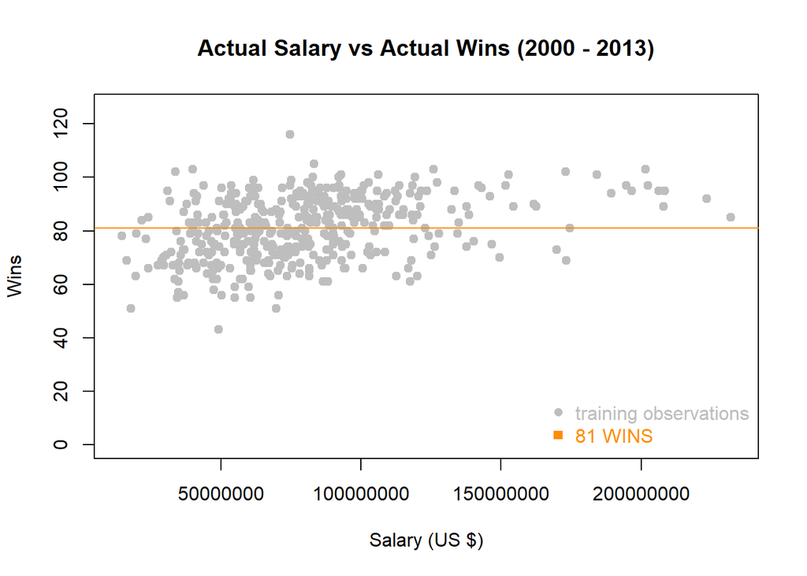

```
##
## Call:
## lm(formula = W ~ salary, data = bbproj_trn)
##
## Residuals:
##     Min      1Q  Median      3Q     Max
## -34.389  -8.180   0.701   8.404  35.659
##
## Coefficients:
##                   Estimate     Std. Error t value           Pr(>|t|)
## (Intercept) 71.70962155199  1.29065984697  55.560            < 2e-16 ***
## salary       0.00000011551  0.00000001468   7.866 0.0000000000000316 ***
## ---
## Signif. codes:  0 '***' 0.001 '**' 0.01 '*' 0.05 '.' 0.1 ' ' 1
##
## Residual standard error: 10.86 on 418 degrees of freedom
## Multiple R-squared:  0.1289, Adjusted R-squared:  0.1269
## F-statistic: 61.87 on 1 and 418 DF,  p-value: 0.00000000000003158
```

```
## [1] "Leave One Out Cross-Validated RMSE:  10.88"
```

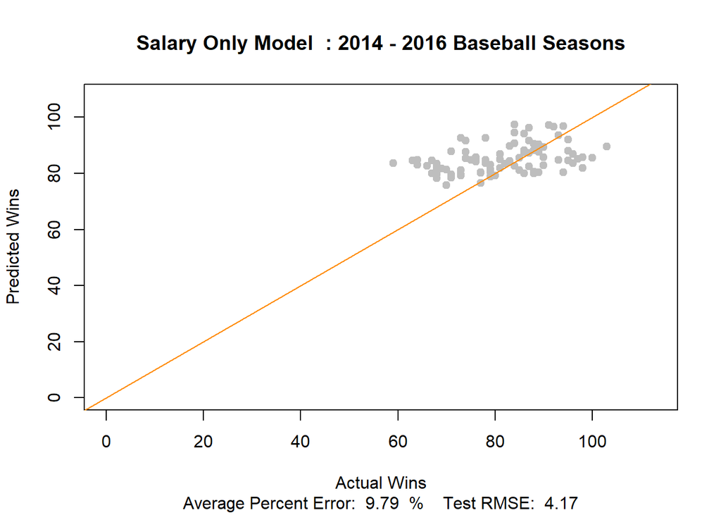

So what are the factors that move the needle?

We explore two related threads in attempting to identify the factors that have a strong impact on a winning baseball team.

The first thread uses multiple linear regression to identify the factors that influence a team’s winning record over the course of a regular Major League Baseball (MLB) season.  
The second thread uses logistic regression to identify the factors that influence a team’s ability to win their division.

## Data

A few words are in order about where we obtained the data from to perform this analysis.

The source of data is the Sean Lahman baseball archive (http://www.seanlahman.com/baseball-archive/), recognized by the *Society for American Baseball Research* (SABR) as the leading detailed player and team data archive from 1874 through the end of the 2017 Major League Baseball season. We use team statistics from the years 2000 through 2013 as the training dataset and use data from 2014 through 2016 as the test dataset. (As a note, we were unable to include the 2017 season in our analysis due to unavailability of salary data.)

### Variables

The team-based variables we examine fall into one of three categories: offensive, defensive, or administrative.

#### Administrative

- `yearID` - Year
- `franchID` - Franchise, or team name
- `W` - **Wins (the multiple linear regression response variable)**
- `DivWin` - **Division winner (Y or N factor- Logistic linear regression response variable)**
- `WCWin` - Wild Card winner (Y or N factor)
- `LgWin` - League champion (Y or N factor)
- `WSWin` - World Series winner (Y or N factor)
- `salary` - Team Salary (U.S dollars not adjusted for inflation)

#### Offensive

- `R` - Runs scored
- `AB` - At bats
- `H` - Total hits (including doubles, triples, and home runs)
- `X1B` - Singles
- `X2B` - Doubles
- `X3B` - Triples
- `HR` - Home runs
- `BB` - Base on balls (walks)
- `SO` - Strikeouts
- `SB` - Stolen bases
- `CS` - Caught stealing
- `HBP` - Hit by pitch
- `SF` - Sacrifice flies
- `park` - Name of team’s home ballpark (factor)
- `attendance` - Home attendance total
- `BPF` - Three-year park factor for batters
- `GIDP` - Grounded into double plays
- `RBI` - Runs Batted In
- `IBB` - Intentional walks
- `TB` - Total bases
- `SLG` - Slugging percentage
- `OBP` - On-base percentage
- `OPS` - On-base plus slugging percentage
- `BABIP` - Batting average for balls in play
- `RC` - Runs created
- `uBB` - Unintentional walks
- `wOBA` - Weighted on-base average

#### Defensive

- `RA` - Total runs allowed
- `ER` - Earned runs allowed
- `ERA` - Earned run average
- `CG` - Complete games
- `SHO` - Shutouts
- `SV` - Saves
- `IPOuts` - Outs pitched
- `HA` - Hits allowed
- `HRA` - Home runs allowed
- `BBA` - Walks allowed
- `SOA` - Strikeouts by pitchers
- `E` - Errors
- `DP` - Double plays
- `FP` - Fielding percentage
- `PPF` - Three-year park factor for pitchers
- `WHIP` - Walks and hits per innings pitched

Notes regarding data preparation may be found in Appendix A, and the calculations end explanations of some of the advanced Sabermetrics included in our dataset may be found in Appendix B.

# The Search for Better Multiple Linear Regression Models For Predicting Regular Season Team Wins

## Methodology

The goal of this thread is to find a Multiple Linear Regression (MLR) model that is simple enough to explain the relationship between the response variable (regular season wins) and the predictors. In essence, we are interested in a reasonably small MLR model that is easy to interpret. Equally important is the need for the model to predict well against the test data set from the 2014, 2015 and 2016 MLB regular seasons. This means we have to sacrifice a certain degree of model simplicity. In short, we are trying to find a model that will allow us to “have our cake and eat it too”.

The approach we take is to employ all three search procedures – *Backward*, *Forward* and *Stepwise* – against the *Akaike Information Criterion* (AIC) and the *Bayesian Information Criterion* (BIC) quality criterion in order to find the model that best meets the goals of this thread.

We start by creating the following six initial models.

- Backward Search - BIC Model
- Backward Search - AIC Model
- Step Search - BIC Model
- Step Search - AIC Model
- Forward Search - BIC Model
- Forward Search - AIC Model.

We then use an iterative process of model evaluation and refinement until we have produced a lineup of candidate models that move on to the next phase of assessment: prediction against the test dataset.

The model evaluation and refinement process utilizes the following six diagnostics tests.

- Breusch-Pagan Test (BP Test) to assess whether each of the six initial models meets the equal variance of residuals requirement. A *p_value* greater than *0.05* indicates a high likelihood that a given model’s errors have constant variance.
- Shapiro-Wilk Test to assess whether each of the six initial models meet the normal distribution of residuals requirement. A *p_value* greater than *0.05* indicates a high likelihood that a given model’s errors are normally distributed.
- A count of the number of unusual observations. The test counts the number of standardized residuals that exceed a magnitude of 2. The threshold for concern is when the count exceeds 5% of the total number of observations.
- Leave One Out Cross-Validated RMSE (LOOCV-RMSE) to assess how well a given model generalizes to unseen observations (e.g., the test data). The smaller the value, the more likely a given model will do a good job predicting the response variable (in this case, regular season wins by an MLB team).
- Calculation of the Variance Inflation Factor (VIF) for each of the estimated predictor coefficients ($\hat{\beta}_j$). A VIF score greater than 5 indicates that a given predictor is highly collinear.
- A check to make sure that the each estimated predictor coefficient ($\hat{\beta}_j$) is likely significant by rejecting the null hypothesis $H_0: B_j = 0$. We fail to reject $H_0: B_j = 0$ when $\hat{\beta}_j$ has a *p_value* greater than *$\alpha = 0.05$*.

If a model passes all six of these diagnostic tests, it is considered worthy of being evaluated against the test dataset. From a nomenclature perspective, each model that passes this hurdle is called a *candidate* model. If a model does not pass all six of these diagnostic tests, we refit the model after removing a single predictor. We then perform the same six diagnostic tests. We repeat this cycle until a model is produced that passes all six of the diagnostic tests.

Once *candidate* models are identified, we assess their ability to predict regular season team wins against the test dataset. The *candidate* model with the lowest *Average Percent Error* and the lowest *Test RMSE* is declared the winner.

Please note that the response variable is designated as **`W`** in models that are described below.

### The Six Initial Multiple Linear Regression Models

```r
scope <- W ~ R + AB + H + X2B + X3B + HR + BB + SO + SB + CS + HBP + SF + RA +
  ER + ERA + CG + SHO + SV + IPouts + HA  + HRA + BBA + SOA + E + DP + FP +
  attendance + BPF + PPF + salary + RBI + GIDP + IBB + TB + SLG + OBP + OPS +
  WHIP + BABIP + RC + X1B + uBB + wOBA

formula <- formula(scope)
start_model <- lm(formula, data= bbproj_trn)
n <- length(resid(start_model))
step_search_start_model <- lm(W ~ 1, data= bbproj_trn)
```

#### Backwards Search: BIC Model

```r
### Backwards Search: BIC Model
bic_model <- step(start_model,  direction = "backward", k = log(n), trace = 0)
summary(bic_model)
```

```
##
## Call:
## lm(formula = W ~ R + AB + H + X2B + BB + SO + CS + SF + RA +
##     CG + SHO + SV + IPouts + HRA + BBA + E + FP + GIDP + BABIP +
##     RC, data = bbproj_trn)
##
## Residuals:
##     Min      1Q  Median      3Q     Max
## -6.8573 -1.9757 -0.1555  1.9118  7.4927
##
## Coefficients:
##                 Estimate   Std. Error t value Pr(>|t|)
## (Intercept)  1297.971349   339.322389   3.825 0.000152 ***
## R               0.076579     0.006140  12.472  < 2e-16 ***
## AB             -0.116786     0.014360  -8.133 5.37e-15 ***
## H               0.306262     0.049740   6.157 1.81e-09 ***
## X2B             0.034285     0.010085   3.399 0.000743 ***
## BB              0.031072     0.006669   4.659 4.33e-06 ***
## SO              0.051706     0.009680   5.341 1.55e-07 ***
## CS             -0.043025     0.015571  -2.763 0.005990 **
## SF             -0.095773     0.021708  -4.412 1.32e-05 ***
## RA             -0.054254     0.003811 -14.238  < 2e-16 ***
## CG              0.148895     0.046962   3.171 0.001639 **
## SHO             0.150078     0.049080   3.058 0.002380 **
## SV              0.345616     0.025203  13.714  < 2e-16 ***
## IPouts          0.057453     0.007126   8.063 8.78e-15 ***
## HRA            -0.026131     0.008530  -3.063 0.002338 **
## BBA            -0.008042     0.002619  -3.070 0.002287 **
## E              -0.182853     0.055690  -3.283 0.001116 **
## FP          -1045.006972   343.178691  -3.045 0.002480 **
## GIDP           -0.044072     0.012147  -3.628 0.000322 ***
## BABIP        -760.159504   137.620611  -5.524 6.00e-08 ***
## RC             -0.115957     0.024057  -4.820 2.04e-06 ***
## ---
## Signif. codes:  0 '***' 0.001 '**' 0.01 '*' 0.05 '.' 0.1 ' ' 1
##
## Residual standard error: 2.729 on 399 degrees of freedom
## Multiple R-squared:  0.9475, Adjusted R-squared:  0.9449
## F-statistic: 360.1 on 20 and 399 DF,  p-value: < 2.2e-16
```

#### Backwards Search: AIC Model

```r
### Backwards Search: AIC Model
aic_model <- step(start_model, direction = "backward", trace = 0)
summary(aic_model)
```

```
##
## Call:
## lm(formula = W ~ R + AB + H + X2B + BB + SO + CS + SF + RA +
##     CG + SHO + SV + IPouts + HRA + BBA + E + FP + BPF + PPF +
##     salary + GIDP + BABIP + RC, data = bbproj_trn)
##
## Residuals:
##     Min      1Q  Median      3Q     Max
## -6.9901 -1.9391 -0.1523  1.9737  7.8582
##
## Coefficients:
##                      Estimate        Std. Error t value Pr(>|t|)
## (Intercept) 1224.786161856054  345.895721393241   3.541 0.000446 ***
## R              0.080154881164    0.006191576342  12.946  < 2e-16 ***
## AB            -0.115370180878    0.014302511665  -8.066 8.71e-15 ***
## H              0.294198894471    0.049836065902   5.903 7.66e-09 ***
## X2B            0.034434010453    0.010055404520   3.424 0.000680 ***
## BB             0.029747234634    0.006800119630   4.375 1.56e-05 ***
## SO             0.048815441474    0.009683749780   5.041 7.06e-07 ***
## CS            -0.044627799778    0.015532577786  -2.873 0.004283 **
## SF            -0.096303670130    0.021621972055  -4.454 1.10e-05 ***
## RA            -0.057347471123    0.004031932044 -14.223  < 2e-16 ***
## CG             0.154701717514    0.046819638380   3.304 0.001039 **
## SHO            0.143225421132    0.048746440530   2.938 0.003495 **
## SV             0.346070608015    0.025076294754  13.801  < 2e-16 ***
## IPouts         0.058770788132    0.007084174725   8.296 1.71e-15 ***
## HRA           -0.022515047089    0.008581255343  -2.624 0.009033 **
## BBA           -0.008098302987    0.002628330947  -3.081 0.002206 **
## E             -0.172337651762    0.056648920630  -3.042 0.002505 **
## FP          -977.032306334171  348.883980530384  -2.800 0.005353 **
## BPF           -0.639264997534    0.233137357795  -2.742 0.006383 **
## PPF            0.599162430182    0.234965627610   2.550 0.011148 *
## salary         0.000000008060    0.000000004559   1.768 0.077838 .
## GIDP          -0.047142718419    0.012117297039  -3.891 0.000117 ***
## BABIP       -723.253375876249  138.139293383540  -5.236 2.67e-07 ***
## RC            -0.109319751926    0.024176237333  -4.522 8.11e-06 ***
## ---
## Signif. codes:  0 '***' 0.001 '**' 0.01 '*' 0.05 '.' 0.1 ' ' 1
##
## Residual standard error: 2.704 on 396 degrees of freedom
## Multiple R-squared:  0.9489, Adjusted R-squared:  0.9459
## F-statistic: 319.4 on 23 and 396 DF,  p-value: < 2.2e-16
```

#### Step Search: BIC Model

```r
### Step Search: BIC Model
step_bic_model <- step(step_search_start_model, scope = scope, direction = "both",
                       k = log(n), trace = 0)
summary(step_bic_model)
```

```
##
## Call:
## lm(formula = W ~ SV + RA + CG + OBP + X3B + SHO + R, data = bbproj_trn)
##
## Residuals:
##     Min      1Q  Median      3Q     Max
## -9.7419 -1.9652  0.0052  1.8342  9.5000
##
## Coefficients:
##              Estimate Std. Error t value       Pr(>|t|)
## (Intercept) 39.123870   6.025094   6.493 0.000000000242 ***
## SV           0.427352   0.025372  16.844        < 2e-16 ***
## RA          -0.076829   0.002616 -29.364        < 2e-16 ***
## CG           0.152982   0.046478   3.292       0.001082 **
## OBP         65.425764  23.940331   2.733       0.006549 **
## X3B         -0.063520   0.016876  -3.764       0.000192 ***
## SHO          0.174222   0.053140   3.279       0.001132 **
## R            0.079990   0.004115  19.439        < 2e-16 ***
## ---
## Signif. codes:  0 '***' 0.001 '**' 0.01 '*' 0.05 '.' 0.1 ' ' 1
##
## Residual standard error: 3.01 on 412 degrees of freedom
## Multiple R-squared:  0.9341, Adjusted R-squared:  0.9329
## F-statistic: 833.7 on 7 and 412 DF,  p-value: < 2.2e-16
```

#### Step Search: AIC Model

```r
### Step Search: AIC Model ###
step_aic_model <- step(step_search_start_model, scope = scope,
                       direction = "both", trace = 0)
summary(step_aic_model)
```

```
##
## Call:
## lm(formula = W ~ SV + RA + CG + X3B + SHO + R + IPouts + AB +
##     H + CS + GIDP + SF + BBA + HRA + E + FP + BPF + PPF + salary +
##     HA, data = bbproj_trn)
##
## Residuals:
##     Min      1Q  Median      3Q     Max
## -7.5195 -1.9115 -0.1021  1.8888  8.0195
##
## Coefficients:
##                      Estimate        Std. Error t value          Pr(>|t|)
## (Intercept)  914.034003146080  347.045241981605   2.634          0.008773 **
## SV             0.355614506804    0.024640390657  14.432           < 2e-16 ***
## RA            -0.050247955833    0.006340159551  -7.925 0.000000000000023 ***
## CG             0.153017526099    0.044231471311   3.459          0.000600 ***
## X3B           -0.068574679286    0.016831959357  -4.074 0.000055748930342 ***
## SHO            0.138199572874    0.049132489791   2.813          0.005154 **
## R              0.084827624066    0.003584776861  23.663           < 2e-16 ***
## IPouts         0.061359854959    0.006880713970   8.918           < 2e-16 ***
## AB            -0.052857166713    0.005932828505  -8.909           < 2e-16 ***
## H              0.049033080922    0.006741047553   7.274 0.000000000001865 ***
## CS            -0.046638144061    0.015078914455  -3.093          0.002121 **
## GIDP          -0.043755357335    0.011669100346  -3.750          0.000203 ***
## SF            -0.052733758025    0.019580831875  -2.693          0.007377 **
## BBA           -0.010442337072    0.003185502948  -3.278          0.001137 **
## HRA           -0.021622522454    0.008707631554  -2.483          0.013432 *
## E             -0.161327447529    0.057050198834  -2.828          0.004923 **
## FP          -884.643492395422  352.491658585804  -2.510          0.012479 *
## BPF           -0.629501587254    0.230983379839  -2.725          0.006707 **
## PPF            0.584792736874    0.231600448463   2.525          0.011956 *
## salary         0.000000007730    0.000000004537   1.704          0.089183 .
## HA            -0.005934333997    0.004089404824  -1.451          0.147524
## ---
## Signif. codes:  0 '***' 0.001 '**' 0.01 '*' 0.05 '.' 0.1 ' ' 1
##
## Residual standard error: 2.727 on 399 degrees of freedom
## Multiple R-squared:  0.9476, Adjusted R-squared:  0.945
## F-statistic: 360.7 on 20 and 399 DF,  p-value: < 2.2e-16
```

#### Forward Search: BIC Model

```r
bic_forward_model <- step(step_search_start_model, scope = scope,
                          k = log(n), trace = 0)
summary(bic_forward_model)
```

```
##
## Call:
## lm(formula = W ~ SV + RA + CG + OBP + X3B + SHO + R, data = bbproj_trn)
##
## Residuals:
##     Min      1Q  Median      3Q     Max
## -9.7419 -1.9652  0.0052  1.8342  9.5000
##
## Coefficients:
##              Estimate Std. Error t value       Pr(>|t|)
## (Intercept) 39.123870   6.025094   6.493 0.000000000242 ***
## SV           0.427352   0.025372  16.844        < 2e-16 ***
## RA          -0.076829   0.002616 -29.364        < 2e-16 ***
## CG           0.152982   0.046478   3.292       0.001082 **
## OBP         65.425764  23.940331   2.733       0.006549 **
## X3B         -0.063520   0.016876  -3.764       0.000192 ***
## SHO          0.174222   0.053140   3.279       0.001132 **
## R            0.079990   0.004115  19.439        < 2e-16 ***
## ---
## Signif. codes:  0 '***' 0.001 '**' 0.01 '*' 0.05 '.' 0.1 ' ' 1
##
## Residual standard error: 3.01 on 412 degrees of freedom
## Multiple R-squared:  0.9341, Adjusted R-squared:  0.9329
## F-statistic: 833.7 on 7 and 412 DF,  p-value: < 2.2e-16
```

#### Forward Search: AIC Model

```r
aic_forward_model <- step(step_search_start_model, scope = scope, trace = 0)
summary(aic_forward_model)
```

```
##
## Call:
## lm(formula = W ~ SV + RA + CG + X3B + SHO + R + IPouts + AB +
##     H + CS + GIDP + SF + BBA + HRA + E + FP + BPF + PPF + salary +
##     HA, data = bbproj_trn)
##
## Residuals:
##     Min      1Q  Median      3Q     Max
## -7.5195 -1.9115 -0.1021  1.8888  8.0195
##
## Coefficients:
##                      Estimate        Std. Error t value          Pr(>|t|)
## (Intercept)  914.034003146080  347.045241981605   2.634          0.008773 **
## SV             0.355614506804    0.024640390657  14.432           < 2e-16 ***
## RA            -0.050247955833    0.006340159551  -7.925 0.000000000000023 ***
## CG             0.153017526099    0.044231471311   3.459          0.000600 ***
## X3B           -0.068574679286    0.016831959357  -4.074 0.000055748930342 ***
## SHO            0.138199572874    0.049132489791   2.813          0.005154 **
## R              0.084827624066    0.003584776861  23.663           < 2e-16 ***
## IPouts         0.061359854959    0.006880713970   8.918           < 2e-16 ***
## AB            -0.052857166713    0.005932828505  -8.909           < 2e-16 ***
## H              0.049033080922    0.006741047553   7.274 0.000000000001865 ***
## CS            -0.046638144061    0.015078914455  -3.093          0.002121 **
## GIDP          -0.043755357335    0.011669100346  -3.750          0.000203 ***
## SF            -0.052733758025    0.019580831875  -2.693          0.007377 **
## BBA           -0.010442337072    0.003185502948  -3.278          0.001137 **
## HRA           -0.021622522454    0.008707631554  -2.483          0.013432 *
## E             -0.161327447529    0.057050198834  -2.828          0.004923 **
## FP          -884.643492395422  352.491658585804  -2.510          0.012479 *
## BPF           -0.629501587254    0.230983379839  -2.725          0.006707 **
## PPF            0.584792736874    0.231600448463   2.525          0.011956 *
## salary         0.000000007730    0.000000004537   1.704          0.089183 .
## HA            -0.005934333997    0.004089404824  -1.451          0.147524
## ---
## Signif. codes:  0 '***' 0.001 '**' 0.01 '*' 0.05 '.' 0.1 ' ' 1
##
## Residual standard error: 2.727 on 399 degrees of freedom
## Multiple R-squared:  0.9476, Adjusted R-squared:  0.945
## F-statistic: 360.7 on 20 and 399 DF,  p-value: < 2.2e-16
```

### Identifying which of the Six Initial Models make the Cut as Candidate Models

#### Evaluation of the Backwards Search: BIC Model

```r
### Breusch-Pagan Test on Backwards Search - BIC Model
bptest(bic_model)
```

```
##
##  studentized Breusch-Pagan test
##
## data:  bic_model
## BP = 19.912, df = 20, p-value = 0.4635
```

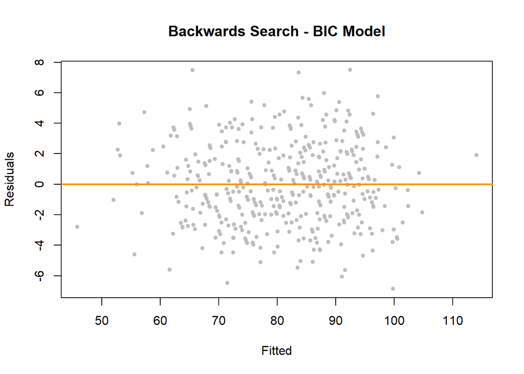

```r
plot_fitted_versus_residuals(fitted(bic_model),
                             resid(bic_model),
                             "Backwards Search - BIC Model")
```

```r
### Shapiro - Wilk Normality Test on Backwards Search - BIC Model ###
shapiro.test(resid(bic_model))
```

```
##
##  Shapiro-Wilk normality test
##
## data:  resid(bic_model)
## W = 0.99328, p-value = 0.05825
```

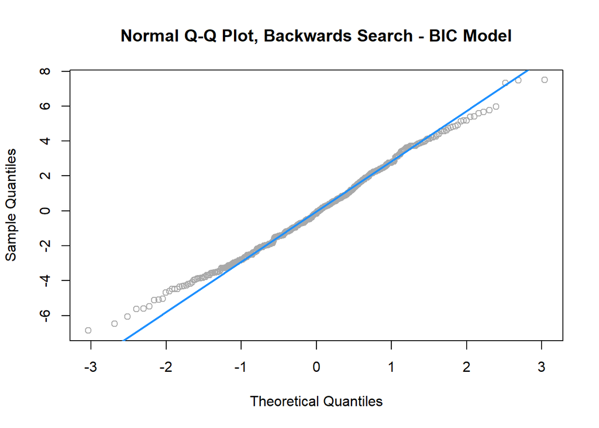

```r
qqnorm(resid(bic_model),
       main = "Normal Q-Q Plot, Backwards Search - BIC Model",
       col = "darkgrey")
qqline(resid(bic_model), col = "dodgerblue", lwd = 2)
```

```r
print(paste("Leave One Out Cross-Validated RMSE: ",
            round(calc_loocv_rmse(bic_model), 2)))
```

```
## [1] "Leave One Out Cross-Validated RMSE:  2.81"
```

```r
### Do the number of standard residuals greater than 2 exceed 5% of the total
### observations -- Backwards Search: BIC Model
std_resid_bic_model <- rstandard(bic_model)[abs(rstandard(bic_model)) > 2]
is_std_resid_gt_five_percent_bic_model <-
  length(std_resid_bic_model) / n > 0.05
ifelse(is_std_resid_gt_five_percent_bic_model,
       "Outliers Exceed 5% of Obs",
       "Outliers Do Not Exceed 5% of Obs")
```

```
## [1] "Outliers Do Not Exceed 5% of Obs"
```

```r
### VIF > 5 for Backwards Search: BIC Model Coefficients
vif_bic_model <- vif(bic_model)
vif_bic_model[which(vif_bic_model > 5)]
```

```
##          R         AB          H         BB         SO         RA          E         FP      BABIP         RC
##  14.894205  72.403111 929.925966  12.247576  80.989904   6.226679  48.143435  48.871767 122.560946 226.450179
```

#### Refining the Backwards Search: BIC Model Due to High Variance Inflation Factors

```r
library(caret)
```

```r
bic_model_high_vif_cols <- c("R", "AB", "H", "BB", "SO", "RA", "E", "FP",
                             "BABIP", "RC")
indices_to_drop <- findCorrelation(cor(bbproj_trn[,c(bic_model_high_vif_cols)]),
                                   cutoff = 0.6)
(vars_to_drop <- bic_model_high_vif_cols[indices_to_drop])
```

```
## [1] "H"  "RC" "R"  "FP"
```

##### A Better and Smaller Backwards Search: BIC Model

```r
smaller_bic_model <- lm(W ~ AB + BB + SO + SF + RA + CG + SV + IPouts + BBA +
                          BABIP, data = bbproj_trn)
summary(smaller_bic_model)
```

```
##
## Call:
## lm(formula = W ~ AB + BB + SO + SF + RA + CG + SV + IPouts +
##     BBA + BABIP, data = bbproj_trn)
##
## Residuals:
##      Min       1Q   Median       3Q      Max
## -13.0090  -3.1465   0.0746   3.1017  13.2658
##
## Coefficients:
##               Estimate Std. Error t value       Pr(>|t|)
## (Intercept) -61.891791  33.514874  -1.847       0.065513 .
## AB            0.035857   0.005639   6.358 0.000000000546 ***
## BB            0.055611   0.003754  14.812        < 2e-16 ***
## SO           -0.008264   0.002508  -3.296       0.001067 **
## SF            0.083700   0.033456   2.502       0.012746 *
## RA           -0.070294   0.004609 -15.250        < 2e-16 ***
## CG            0.335688   0.080389   4.176 0.000036315586 ***
## SV            0.599497   0.041742  14.362        < 2e-16 ***
## IPouts       -0.019466   0.010220  -1.905       0.057516 .
## BBA          -0.008600   0.004530  -1.898       0.058341 .
## BABIP       118.264318  33.616837   3.518       0.000484 ***
## ---
## Signif. codes:  0 '***' 0.001 '**' 0.01 '*' 0.05 '.' 0.1 ' ' 1
##
## Residual standard error: 4.888 on 409 degrees of freedom
## Multiple R-squared:  0.8274, Adjusted R-squared:  0.8231
## F-statistic:   196 on 10 and 409 DF,  p-value: < 2.2e-16
```

##### Diagnostics for the Better and Smaller Backwards Search: BIC Model

```r
model_diagnostics(smaller_bic_model)
```

```
## [1] "Variance Inflation Factors"
##       AB       BB       SO       SF       RA       CG       SV   IPouts      BBA    BABIP
## 3.480184 1.210000 1.693955 1.472823 2.839735 1.243693 1.573034 2.843318 1.558630 2.279289
## [1] "Number of coefficients with VIF > 5:  0"
##
##  studentized Breusch-Pagan test
##
## data:  model
## BP = 13.488, df = 10, p-value = 0.1976
##
##
##  Shapiro-Wilk normality test
##
## data:  resid(model)
## W = 0.99706, p-value = 0.6567
##
## [1] "Leave One Out Cross-Validated RMSE:  4.95"
## [1] "Outliers Exceed 5% of Obs"
```

#### Evaluation of the Backwards Search: AIC Model

```r
### Breusch-Pagan Test on AIC Model
bptest(aic_model)
```

```
##
##  studentized Breusch-Pagan test
##
## data:  aic_model
## BP = 22.713, df = 23, p-value = 0.4777
```

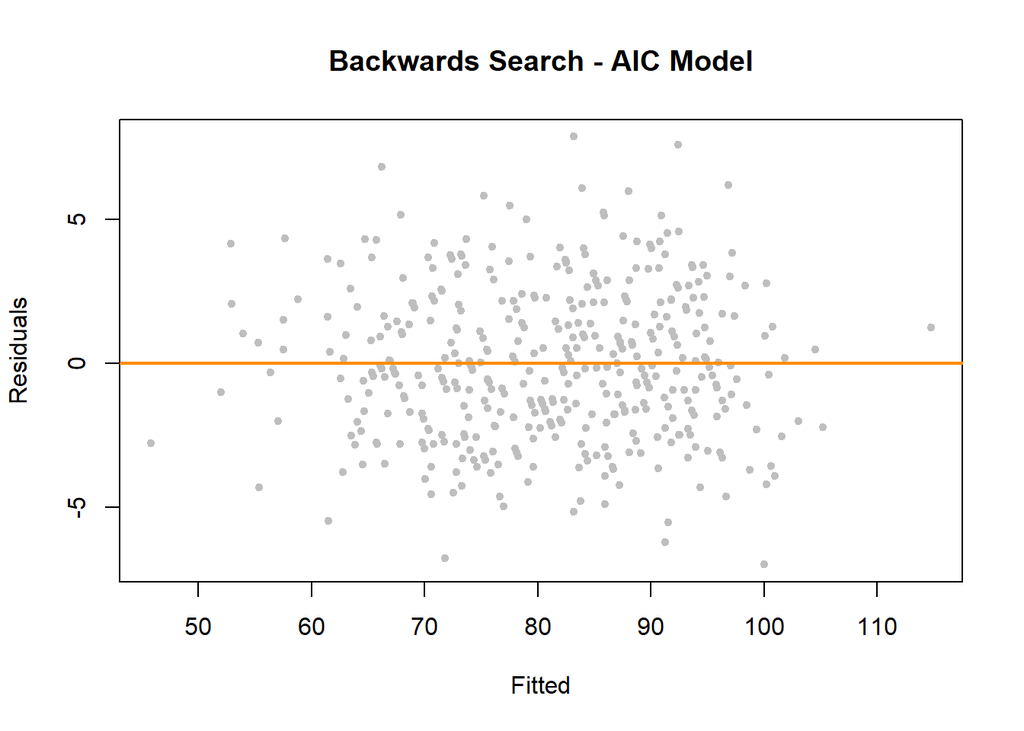

```r
plot_fitted_versus_residuals(fitted(aic_model), resid(aic_model),
                             "Backwards Search - AIC Model")
```

```r
### Shapiro - Wilk Normality Test on Backwards Search - AIC Model ###
shapiro.test(resid(aic_model))
```

```
##
##  Shapiro-Wilk normality test
##
## data:  resid(aic_model)
## W = 0.99355, p-value = 0.07005
```

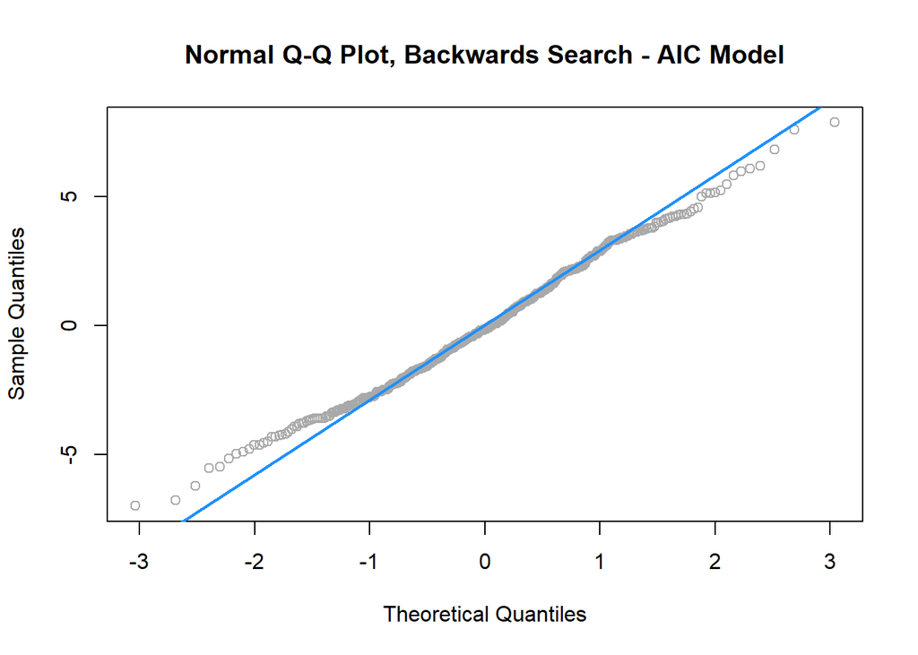

```
## [1] "Leave One Out Cross-Validated RMSE:  2.79"
```

```r
qqnorm(resid(aic_model),
       main = "Normal Q-Q Plot, Backwards Search - AIC Model",
       col = "darkgrey")
qqline(resid(aic_model), col = "dodgerblue", lwd = 2)
```

```r
### Do the number of standard residuals greater than 2 exceed 5% of the total
### observations -- Backwards Search: AIC Model
std_resid_aic_model <- rstandard(aic_model)[abs(rstandard(aic_model)) > 2]
is_std_resid_gt_five_percent_aic_model <-
  length(std_resid_aic_model) / n > 0.05
ifelse(is_std_resid_gt_five_percent_aic_model,
       "Outliers Exceed 5% of Obs",
       "Outliers Do Not Exceed 5% of Obs")
```

```
## [1] "Outliers Do Not Exceed 5% of Obs"
```

```r
### VIF > 5 for Backwards Search: AIC Model Coefficients
vif_aic_model <- vif(aic_model)
vif_aic_model[which(vif_aic_model > 5)]
```

```
##          R         AB          H         BB         SO         RA          E         FP        BPF        PPF      BABIP         RC
##  15.427663  73.154978 950.861657  12.972390  82.555959   7.100542  50.740746  51.448558  85.281044  84.114946 125.780508 232.943354
```

#### Refining the Backwards Search: AIC Model Due to High Variance Inflation Factors

```r
aic_model_high_vif_cols <- c("R", "AB", "H", "X2B", "X3B", "HR", "BB", "SO",
                             "SF", "RA", "ER", "IPouts", "E", "FP","BPF",
                             "PPF", "IBB", "OBP", "BABIP", "RC", "wOBA")
indices_to_drop <- findCorrelation(cor(bbproj_trn[,c(aic_model_high_vif_cols)]),
                                   cutoff = 0.6)
(vars_to_drop <- aic_model_high_vif_cols[indices_to_drop])
```

```
## [1] "RC"   "wOBA" "R"    "OBP"  "H"    "RA"   "BPF"  "FP"
```

##### A Better and Smaller Backwards Search: AIC Model

```r
smaller_aic_model <-  lm(formula = W ~  HR + BB + SO + ER + CG + SHO + SV +
                           IPouts + BBA + FP + GIDP + BABIP, data = bbproj_trn)
summary(smaller_aic_model)
```

```
##
## Call:
## lm(formula = W ~ HR + BB + SO + ER + CG + SHO + SV + IPouts +
##     BBA + FP + GIDP + BABIP, data = bbproj_trn)
##
## Residuals:
##     Min      1Q  Median      3Q     Max
## -8.3371 -2.5236 -0.0841  2.1182 10.2418
##
## Coefficients:
##                Estimate  Std. Error t value   Pr(>|t|)
## (Intercept) -328.428863   67.755211  -4.847 0.00000178 ***
## HR             0.132223    0.005998  22.044    < 2e-16 ***
## BB             0.032238    0.002798  11.523    < 2e-16 ***
## SO            -0.023360    0.001674 -13.952    < 2e-16 ***
## ER            -0.068993    0.003633 -18.993    < 2e-16 ***
## CG             0.189266    0.057990   3.264   0.001192 **
## SHO            0.235242    0.061006   3.856   0.000134 ***
## SV             0.410129    0.030171  13.593    < 2e-16 ***
## IPouts         0.014815    0.005185   2.857   0.004495 **
## BBA           -0.008063    0.003203  -2.517   0.012216 *
## FP           278.765319   69.652956   4.002 0.00007457 ***
## GIDP          -0.037475    0.012793  -2.929   0.003589 **
## BABIP        316.088714   16.896493  18.707    < 2e-16 ***
## ---
## Signif. codes:  0 '***' 0.001 '**' 0.01 '*' 0.05 '.' 0.1 ' ' 1
##
## Residual standard error: 3.435 on 407 degrees of freedom
## Multiple R-squared:  0.9152, Adjusted R-squared:  0.9127
## F-statistic: 365.9 on 12 and 407 DF,  p-value: < 2.2e-16
```

##### Diagnostics for the Better and Smaller Backwards Search: AIC Model

```r
model_diagnostics(smaller_aic_model)
```

```
## [1] "Variance Inflation Factors"
##       HR       BB       SO       ER       CG      SHO       SV   IPouts      BBA       FP     GIDP    BABIP
## 1.426241 1.360620 1.529067 3.064298 1.310541 1.907533 1.664221 1.482259 1.578259 1.270639 1.409269 1.166015
## [1] "Number of coefficients with VIF > 5:  0"
##
##  studentized Breusch-Pagan test
##
## data:  model
## BP = 8.7708, df = 12, p-value = 0.7224
##
##
##  Shapiro-Wilk normality test
##
## data:  resid(model)
## W = 0.99241, p-value = 0.03137
##
## [1] "Leave One Out Cross-Validated RMSE:  3.49"
## [1] "Outliers Exceed 5% of Obs"
```

The Smaller Backward Search: AIC model does not pass all six of the diagnostic tests. The Shapiro-Wilk p-value is smaller than the threshold of $\alpha = 0.05$. As a result, we reject the null hypothesis that the residuals are normally distributed. As such, this model is not deemed a *candidate* model and is not passed on to the next evaluation phase.

#### Evaluation of the Step Search: BIC Model

```r
### Breusch-Pagan Test on Step BIC Model
bptest(step_bic_model)
```

```
##
##  studentized Breusch-Pagan test
##
## data:  step_bic_model
## BP = 3.0387, df = 7, p-value = 0.8814
```

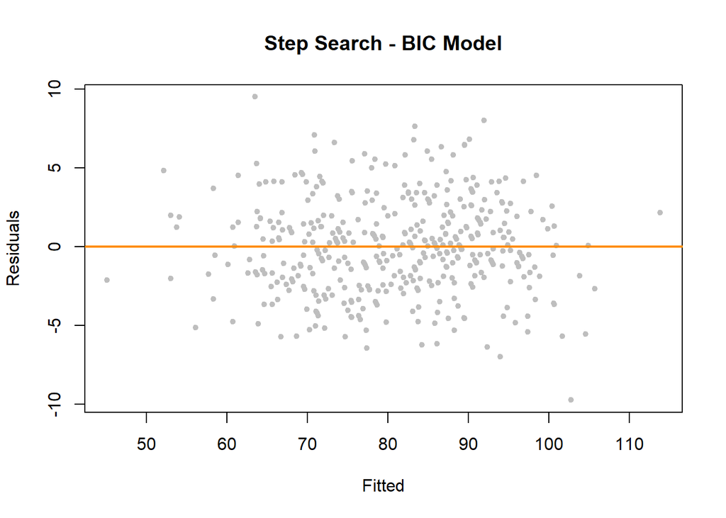

```r
plot_fitted_versus_residuals(fitted(step_bic_model), resid(step_bic_model),
                             "Step Search - BIC Model")
```

```r
### Shapiro - Wilk Normality Test on Step Search - BIC Model ###
shapiro.test(resid(step_bic_model))
```

```
##
##  Shapiro-Wilk normality test
##
## data:  resid(step_bic_model)
## W = 0.99708, p-value = 0.6604
```

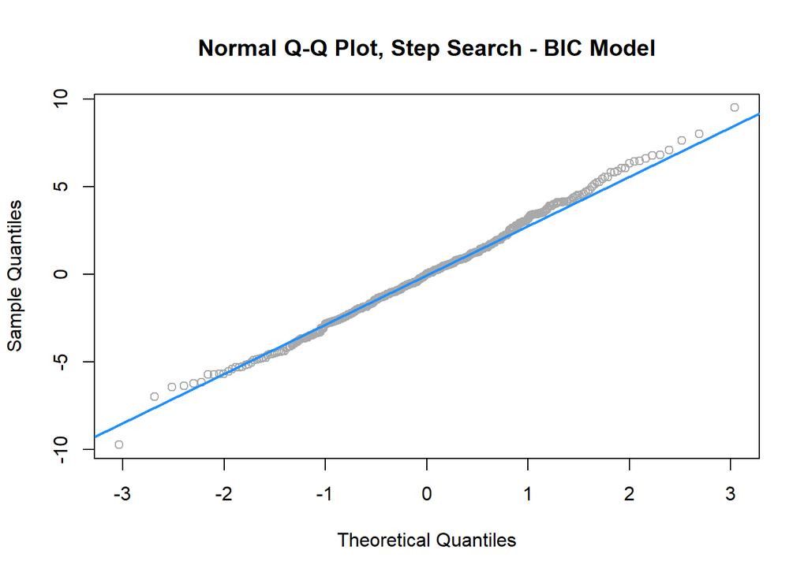

```
## [1] "Leave One Out Cross-Validated RMSE:  3.04"
```

```r
qqnorm(resid(step_bic_model),
       main = "Normal Q-Q Plot, Step Search - BIC Model",
       col = "darkgrey")
qqline(resid(step_bic_model), col = "dodgerblue", lwd = 2)
```

```r
### Do the number of standard residuals greater than 2 exceed 5% of the total
### observations -- Step Search: BIC Model
std_resid_step_bic_model <- rstandard(
  step_bic_model)[abs(rstandard(step_bic_model)) > 2]
is_std_resid_gt_five_percent__step_bic_model <- length(
  std_resid_step_bic_model) / n > 0.05
ifelse(is_std_resid_gt_five_percent__step_bic_model, "Exceeds 5% of Obs",
       "Does Not Exceed 5% of Obs")
```

```
## [1] "Does Not Exceed 5% of Obs"
```

```r
### VIF > 5 for Step Search: BIC Model Coefficients
vif_step_bic_model <- vif(step_bic_model)
vif_step_bic_model[which(vif_step_bic_model > 5)]
```

```
##      OBP        R
## 5.221787 5.499516
```

#### Refining the Step Search: BIC Model Due to High Variance Inflation Factors

##### A Better and Smaller Step Search: BIC Model

```r
smaller_step_bic_model <- lm(formula = W ~ SV + R + RA + SHO + CG + X3B +
                               IPouts + AB + salary, data = bbproj_trn)
summary(smaller_step_bic_model)
```

```
##
## Call:
## lm(formula = W ~ SV + R + RA + SHO + CG + X3B + IPouts + AB +
##     salary, data = bbproj_trn)
##
## Residuals:
##     Min      1Q  Median      3Q     Max
## -8.6930 -2.0156  0.0027  1.8031  8.6432
##
## Coefficients:
##                   Estimate     Std. Error t value  Pr(>|t|)
## (Intercept) 16.64791877157 19.43171439428   0.857   0.39209
## SV           0.39794921940  0.02548723971  15.614   < 2e-16 ***
## R            0.09465788997  0.00239639476  39.500   < 2e-16 ***
## RA          -0.07000030397  0.00295754734 -23.668   < 2e-16 ***
## SHO          0.17217667234  0.05222372960   3.297   0.00106 **
## CG           0.14266098090  0.04629864831   3.081   0.00220 **
## X3B         -0.04901240782  0.01691431490  -2.898   0.00396 **
## IPouts       0.02307347246  0.00528945937   4.362 0.0000163 ***
## AB          -0.01298730710  0.00293489287  -4.425 0.0000124 ***
## salary       0.00000001035  0.00000000449   2.305   0.02167 *
## ---
## Signif. codes:  0 '***' 0.001 '**' 0.01 '*' 0.05 '.' 0.1 ' ' 1
##
## Residual standard error: 2.95 on 410 degrees of freedom
## Multiple R-squared:  0.937,  Adjusted R-squared:  0.9356
## F-statistic: 677.2 on 9 and 410 DF,  p-value: < 2.2e-16
```

##### Diagnostics for the Better and Smaller Step Search: BIC Model

```r
model_diagnostics(smaller_step_bic_model)
```

```
## [1] "Variance Inflation Factors"
##       SV        R       RA      SHO       CG      X3B   IPouts       AB   salary
## 1.610244 1.941649 3.209850 1.895339 1.132668 1.067672 2.091258 2.587975 1.267406
## [1] "Number of coefficients with VIF > 5:  0"
##
##  studentized Breusch-Pagan test
##
## data:  model
## BP = 4.372, df = 9, p-value = 0.8853
##
##
##  Shapiro-Wilk normality test
##
## data:  resid(model)
## W = 0.9967, p-value = 0.549
##
## [1] "Leave One Out Cross-Validated RMSE:  2.99"
## [1] "Outliers Do Not Exceed 5% of Obs"
```

The Smaller Step Search: BIC model passes all six of the diagnostic tests. It is deemed as a *candidate* model for the next phase: evaluation of the model’s predictive capability against the test dataset.

#### Evaluation of the Step Search: AIC Model

```r
### Breusch-Pagan Test on Step AIC Model
bptest(step_aic_model)
```

```
##
##  studentized Breusch-Pagan test
##
## data:  step_aic_model
## BP = 22.885, df = 20, p-value = 0.2945
```

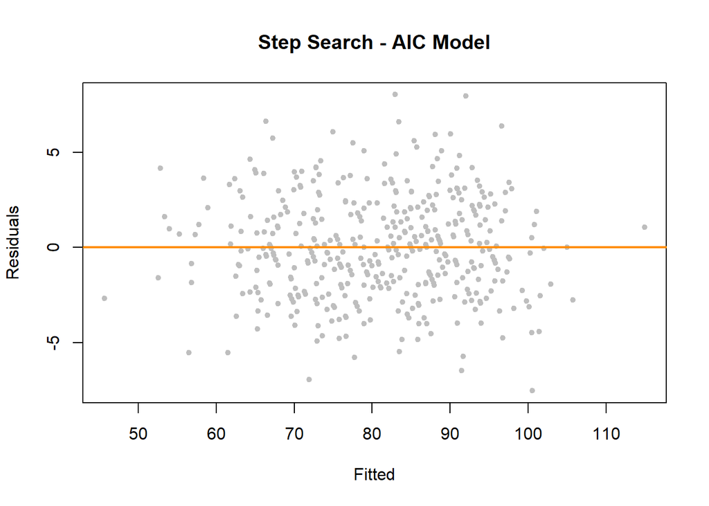

```r
plot_fitted_versus_residuals(fitted(step_aic_model), resid(step_aic_model),
                             "Step Search - AIC Model")
```

```r
### Shapiro - Wilk Normality Test on Step Search - AIC Model ###
shapiro.test(resid(step_aic_model))
```

```
##
##  Shapiro-Wilk normality test
##
## data:  resid(step_aic_model)
## W = 0.99683, p-value = 0.5883
```

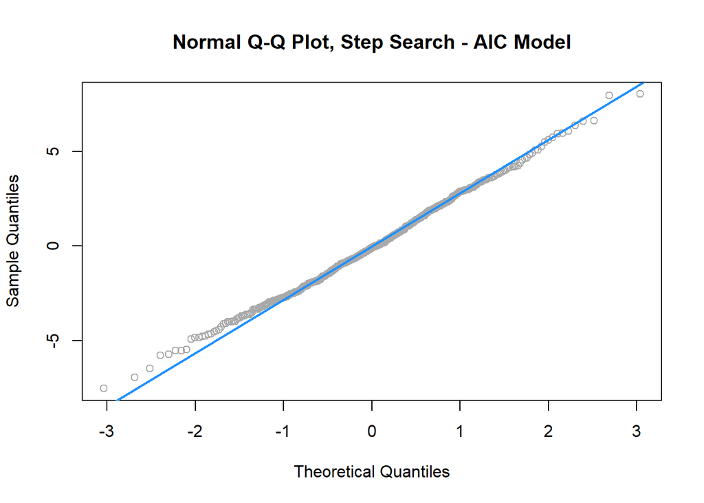

```
## [1] "Leave One Out Cross-Validated RMSE:  2.8"
```

```r
qqnorm(resid(step_aic_model),
       main = "Normal Q-Q Plot, Step Search - AIC Model",
       col = "darkgrey")
qqline(resid(step_aic_model), col = "dodgerblue", lwd = 2)
```

```r
### Do the number of standard residuals greater than 2 exceed 5% of the total
### observations -- Step Search: AIC Model
std_resid_step_aic_model <- rstandard(
  step_aic_model)[abs(rstandard(step_aic_model)) > 2]
is_std_resid_gt_five_percent__step_aic_model <- length(
  std_resid_step_aic_model) / n > 0.05
ifelse(is_std_resid_gt_five_percent__step_aic_model,
       "Exceeds 5% of Obs",
       "Does Not Exceed 5% of Obs")
```

```
## [1] "Does Not Exceed 5% of Obs"
```

```r
### VIF > 5 for Step Search: AIC Model Coefficients
vif_step_aic_model <- vif(step_aic_model)
vif_step_aic_model[which(vif_step_aic_model > 5)]
```

```
##        RA         R        AB         H         E        FP       BPF       PPF        HA
## 17.262491  5.084637 12.376016 17.104981 50.597130 51.635315 82.305380 80.349149  7.123143
```

#### Refining the Step Search: AIC Model Due to High Variance Inflation Factors

##### A Better and Smaller Step Search: AIC Model

```r
smaller_step_aic_model <- lm(formula = W ~ SV + R + SHO + CG + X3B + IPouts +
                               BBA + HRA + SOA, data = bbproj_trn)
summary(smaller_step_aic_model)
```

```
##
## Call:
## lm(formula = W ~ SV + R + SHO + CG + X3B + IPouts + BBA + HRA +
##     SOA, data = bbproj_trn)
##
## Residuals:
##      Min       1Q   Median       3Q      Max
## -11.9548  -2.9275   0.2111   2.5960  15.3693
##
## Coefficients:
##                Estimate  Std. Error t value          Pr(>|t|)
## (Intercept) -106.910065   24.782771  -4.314 0.000020123812728 ***
## SV             0.553970    0.033062  16.756           < 2e-16 ***
## R              0.082172    0.002520  32.612           < 2e-16 ***
## SHO            0.459052    0.068216   6.729 0.000000000057562 ***
## CG             0.295343    0.063584   4.645 0.000004589228066 ***
## X3B           -0.063341    0.022615  -2.801           0.00534 **
## IPouts         0.026697    0.005825   4.583 0.000006087870449 ***
## BBA           -0.027269    0.003450  -7.905 0.000000000000025 ***
## HRA           -0.098460    0.009868  -9.978           < 2e-16 ***
## SOA            0.013936    0.001999   6.970 0.000000000012736 ***
## ---
## Signif. codes:  0 '***' 0.001 '**' 0.01 '*' 0.05 '.' 0.1 ' ' 1
##
## Residual standard error: 4.006 on 410 degrees of freedom
## Multiple R-squared:  0.8837, Adjusted R-squared:  0.8812
## F-statistic: 346.3 on 9 and 410 DF,  p-value: < 2.2e-16
```

##### Diagnostics for the Better and Smaller Step Search: AIC Model

```r
model_diagnostics(smaller_step_aic_model)
```

```
## [1] "Variance Inflation Factors"
##       SV        R      SHO       CG      X3B   IPouts      BBA      HRA      SOA
## 1.468999 1.163807 1.753261 1.158178 1.034795 1.375007 1.345455 1.577315 1.440348
## [1] "Number of coefficients with VIF > 5:  0"
##
##  studentized Breusch-Pagan test
##
## data:  model
## BP = 3.5705, df = 9, p-value = 0.9373
##
##
##  Shapiro-Wilk normality test
##
## data:  resid(model)
## W = 0.99481, p-value = 0.1694
##
## [1] "Leave One Out Cross-Validated RMSE:  4.05"
## [1] "Outliers Do Not Exceed 5% of Obs"
```

The Smaller Step Search: AIC model passes all six of the diagnostic tests. It is deemed as a *candidate* model for the next phase: evaluation of the model’s predictive capability against the test dataset.

#### Evaluation of the Forward Search: BIC Model

```r
### Breusch-Pagan Test
bptest(bic_forward_model)
```

```
##
##  studentized Breusch-Pagan test
##
## data:  bic_forward_model
## BP = 3.0387, df = 7, p-value = 0.8814
```

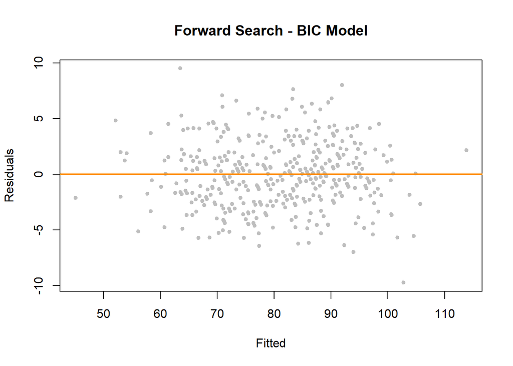

```r
plot_fitted_versus_residuals(fitted(bic_forward_model),
                             resid(bic_forward_model),
                             "Forward Search - BIC Model")
```

```r
### Shapiro - Wilk Normality Test ###
shapiro.test(resid(bic_forward_model))
```

```
##
##  Shapiro-Wilk normality test
##
## data:  resid(bic_forward_model)
## W = 0.99708, p-value = 0.6604
```

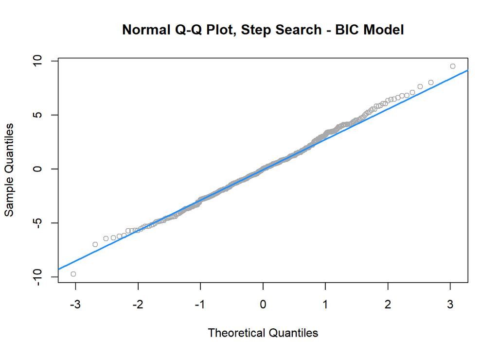

```
## [1] "Leave One Out Cross-Validated RMSE:  3.04"
```

```r
qqnorm(resid(bic_forward_model),
       main = "Normal Q-Q Plot, Step Search - BIC Model", col = "darkgrey")
qqline(resid(bic_forward_model), col = "dodgerblue", lwd = 2)
```

```r
### Do the number of standard residuals greater than 2 exceed 5% of the total
### observations -- Step Search: AIC Model
std_resid <- rstandard(bic_forward_model)[abs(rstandard(bic_forward_model)) > 2]
is_std_resid_gt_five_percent <- length(std_resid) / n > 0.05
ifelse(is_std_resid_gt_five_percent, "Exceeds 5% of Obs",
       "Does Not Exceed 5% of Obs")
```

```
## [1] "Does Not Exceed 5% of Obs"
```

```r
### VIF > 5 for Step Search: AIC Model Coefficients
vifs <- vif(bic_forward_model)
vifs[which(vifs > 5)]
```

```
##      OBP        R
## 5.221787 5.499516
```

#### Refining the Forward Search: BIC Model Due to High Variance Inflation Factors

```r
high_vif_cols <- as.array(names(vifs[which(vifs > 5)]))
indices_to_drop <- findCorrelation(cor(bbproj_trn[,c(high_vif_cols)]),
                                   cutoff = 0.6)
(vars_to_drop <- high_vif_cols[indices_to_drop])
```

```
## [1] "R"
```

##### A Better and Smaller Forward Search: BIC Model

```r
terms = attr(bic_forward_model$terms, "term.labels")
terms = terms[! terms %in% vars_to_drop]
formula = as.formula(paste("W ~", paste(terms, collapse = "+")))
smaller_model <- lm(formula = formula, data = bbproj_trn)
summary(smaller_model)
```

```
##
## Call:
## lm(formula = formula, data = bbproj_trn)
##
## Residuals:
##      Min       1Q   Median       3Q      Max
## -11.2187  -2.7593  -0.0139   2.6440  11.9379
##
## Coefficients:
##               Estimate Std. Error t value  Pr(>|t|)
## (Intercept) -48.379453   5.538267  -8.735   < 2e-16 ***
## SV            0.510814   0.034581  14.771   < 2e-16 ***
## RA           -0.067633   0.003559 -19.005   < 2e-16 ***
## CG            0.259678   0.063826   4.069 0.0000567 ***
## OBP         478.519624  15.245069  31.388   < 2e-16 ***
## X3B          -0.058658   0.023336  -2.514    0.0123 *
## SHO           0.166892   0.073487   2.271    0.0237 *
## ---
## Signif. codes:  0 '***' 0.001 '**' 0.01 '*' 0.05 '.' 0.1 ' ' 1
##
## Residual standard error: 4.162 on 413 degrees of freedom
## Multiple R-squared:  0.8736, Adjusted R-squared:  0.8717
## F-statistic: 475.7 on 6 and 413 DF,  p-value: < 2.2e-16
```

```r
smaller_bic_forward_model = smaller_model
```

##### Diagnostics for the Better and Smaller Forward Search: BIC Model

```r
model_diagnostics(smaller_bic_forward_model)
```

```
## [1] "Variance Inflation Factors"
##       SV       RA       CG      OBP      X3B      SHO
## 1.488879 2.334176 1.081155 1.107182 1.020757 1.884954
## [1] "Number of coefficients with VIF > 5:  0"
##
##  studentized Breusch-Pagan test
##
## data:  model
## BP = 3.5489, df = 6, p-value = 0.7375
##
##
##  Shapiro-Wilk normality test
##
## data:  resid(model)
## W = 0.99807, p-value = 0.9205
##
## [1] "Leave One Out Cross-Validated RMSE:  4.2"
## [1] "Outliers Do Not Exceed 5% of Obs"
```

The Smaller Forward Search: BIC model passes all six of the diagnostic tests. It is deemed as a *candidate* model for the next phase: evaluation of the model’s predictive capability against the test dataset.

#### Evaluation of the Forward Search: AIC Model

```r
### Breusch-Pagan Test
bptest(aic_forward_model)
```

```
##
##  studentized Breusch-Pagan test
##
## data:  aic_forward_model
## BP = 22.885, df = 20, p-value = 0.2945
```

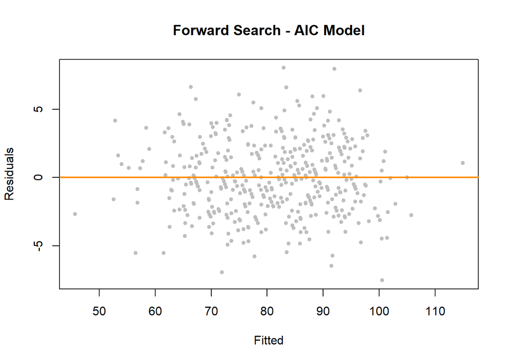

```r
plot_fitted_versus_residuals(fitted(aic_forward_model),
                             resid(aic_forward_model),
                             "Forward Search - AIC Model")
```

```r
### Shapiro - Wilk Normality Test ###
shapiro.test(resid(aic_forward_model))
```

```
##
##  Shapiro-Wilk normality test
##
## data:  resid(aic_forward_model)
## W = 0.99683, p-value = 0.5883
```

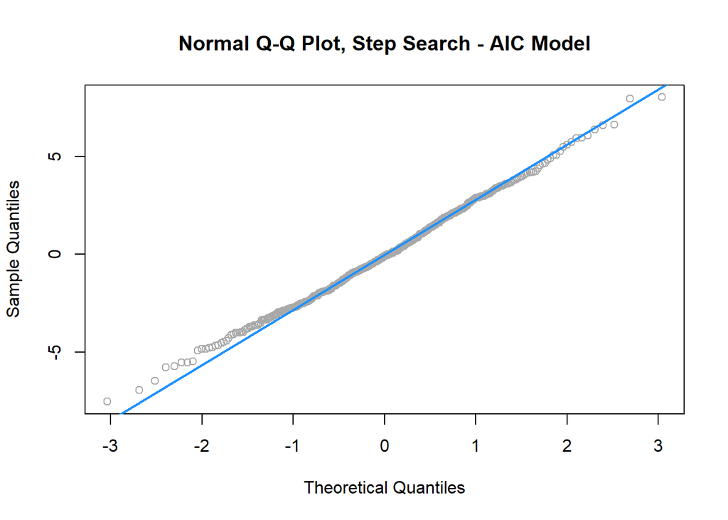

```
## [1] "Leave One Out Cross-Validated RMSE:  2.8"
```

```r
qqnorm(resid(aic_forward_model),
       main = "Normal Q-Q Plot, Step Search - AIC Model", col = "darkgrey")
qqline(resid(aic_forward_model), col = "dodgerblue", lwd = 2)
```

```r
### Do the number of standard residuals greater than 2 exceed 5% of the total
### observations -- Step Search: AIC Model
std_resid <- rstandard(aic_forward_model)[abs(rstandard(aic_forward_model)) > 2]
is_std_resid_gt_five_percent <- length(std_resid) / n > 0.05
ifelse(is_std_resid_gt_five_percent,"Exceeds 5% of Obs",
       "Does Not Exceed 5% of Obs")
```

```
## [1] "Does Not Exceed 5% of Obs"
```

```r
### VIF > 5 for Step Search: AIC Model Coefficients
vifs <- vif(aic_forward_model)
vifs[which(vifs > 5)]
```

```
##        RA         R        AB         H         E        FP       BPF       PPF        HA
## 17.262491  5.084637 12.376016 17.104981 50.597130 51.635315 82.305380 80.349149  7.123143
```

#### Refining the Forward Search: AIC Model Due to High Variance Inflation Factors

```r
high_vif_cols <- as.array(names(vifs[which(vifs > 5)]))
indices_to_drop <- findCorrelation(cor(bbproj_trn[,c(high_vif_cols)]),
                                   cutoff = 0.6)
vars_to_drop <- high_vif_cols[indices_to_drop]
vars_to_drop
```

```
## [1] "H"   "RA"  "R"   "BPF" "FP"
```

##### A Better and Smaller Forward Search: AIC Model

```r
terms = attr(aic_forward_model$terms, "term.labels")
terms = terms[! terms %in% vars_to_drop]
formula = as.formula(paste("W ~", paste(terms, collapse = "+")))
smaller_model <-  lm(formula = formula, data = bbproj_trn)
summary(smaller_model)
```

```
##
## Call:
## lm(formula = formula, data = bbproj_trn)
##
## Residuals:
##      Min       1Q   Median       3Q      Max
## -20.7707  -4.0132   0.0735   3.9381  16.8375
##
## Coefficients:
##                      Estimate        Std. Error t value         Pr(>|t|)
## (Intercept) -130.372691160133   40.942184890385  -3.184         0.001563 **
## SV             0.691822762359    0.051293290999  13.488          < 2e-16 ***
## CG             0.451451517680    0.097869852286   4.613 0.00000534151951 ***
## X3B           -0.044130287173    0.037206097668  -1.186         0.236278
## SHO            0.187051414650    0.110061882108   1.700         0.089993 .
## IPouts         0.006637885812    0.010439115229   0.636         0.525223
## AB             0.035276686983    0.005368182209   6.571 0.00000000015396 ***
## CS            -0.018371247437    0.029837527171  -0.616         0.538433
## GIDP           0.026472866957    0.020953425350   1.263         0.207169
## SF             0.273938786852    0.038676525292   7.083 0.00000000000631 ***
## BBA           -0.020850806318    0.005466335198  -3.814         0.000158 ***
## HRA           -0.033796874832    0.016267982447  -2.078         0.038386 *
## E             -0.045858530274    0.020678376355  -2.218         0.027131 *
## PPF            0.154768090993    0.063792547637   2.426         0.015698 *
## salary         0.000000022080    0.000000009774   2.259         0.024405 *
## HA            -0.037682947274    0.005416312830  -6.957 0.00000000001406 ***
## ---
## Signif. codes:  0 '***' 0.001 '**' 0.01 '*' 0.05 '.' 0.1 ' ' 1
##
## Residual standard error: 6.152 on 404 degrees of freedom
## Multiple R-squared:  0.7299, Adjusted R-squared:  0.7198
## F-statistic: 72.77 on 15 and 404 DF,  p-value: < 2.2e-16
```

```r
smaller_aic_forward_model = smaller_model
```

##### Diagnostics for the Better and Smaller Forward Search: AIC Model

```r
model_diagnostics(smaller_aic_forward_model)
```

```
## [1] "Variance Inflation Factors"
##       SV       CG      X3B      SHO   IPouts       AB       CS     GIDP       SF      BBA      HRA        E      PPF   salary
## 1.499417 1.163642 1.187716 1.935442 1.872698 1.990606 1.231270 1.178478 1.242515 1.432725 1.817827 1.305924 1.197612 1.380530
##       HA
## 2.454893
## [1] "Number of coefficients with VIF > 5:  0"
##
##  studentized Breusch-Pagan test
##
## data:  model
## BP = 20.617, df = 15, p-value = 0.1495
##
##
##  Shapiro-Wilk normality test
##
## data:  resid(model)
## W = 0.9972, p-value = 0.6962
##
## [1] "Leave One Out Cross-Validated RMSE:  6.27"
## [1] "Outliers Do Not Exceed 5% of Obs"
```

### Validate the Candidate Model Predictive Effectiveness using Test Data

We now move forward with five *candidate* models and predict MLB regular season team wins with our test dataset from the 2014, 2015 and 2016 MLB regular seasons. (There are a total of 90 observations in the test dataset – one observation for each team for 2014, 2015 and 2016.)

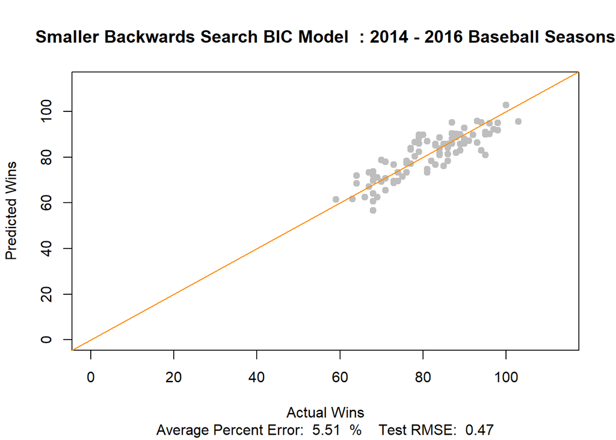

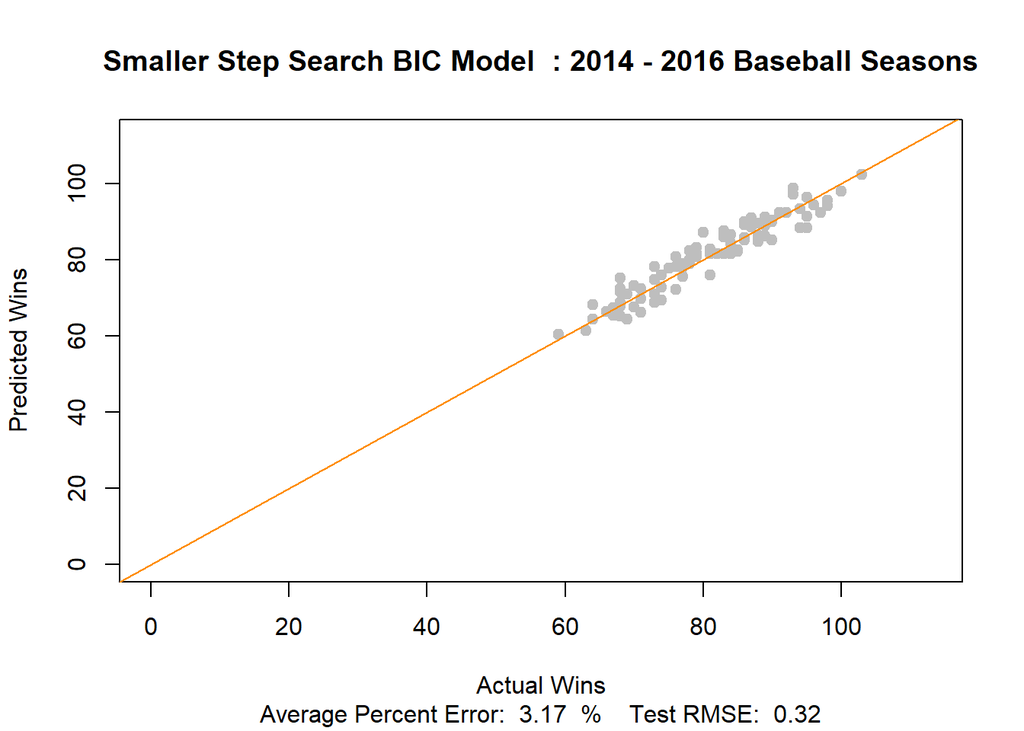

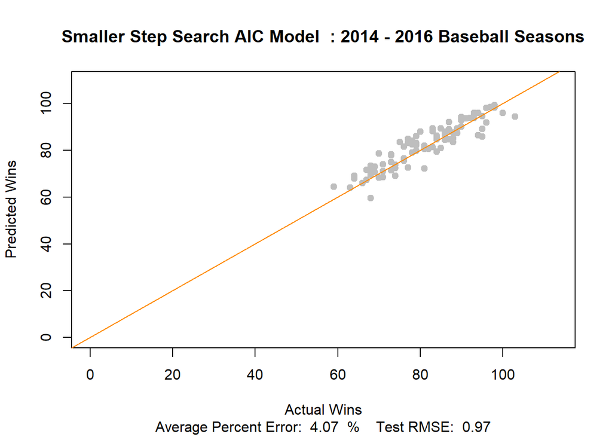

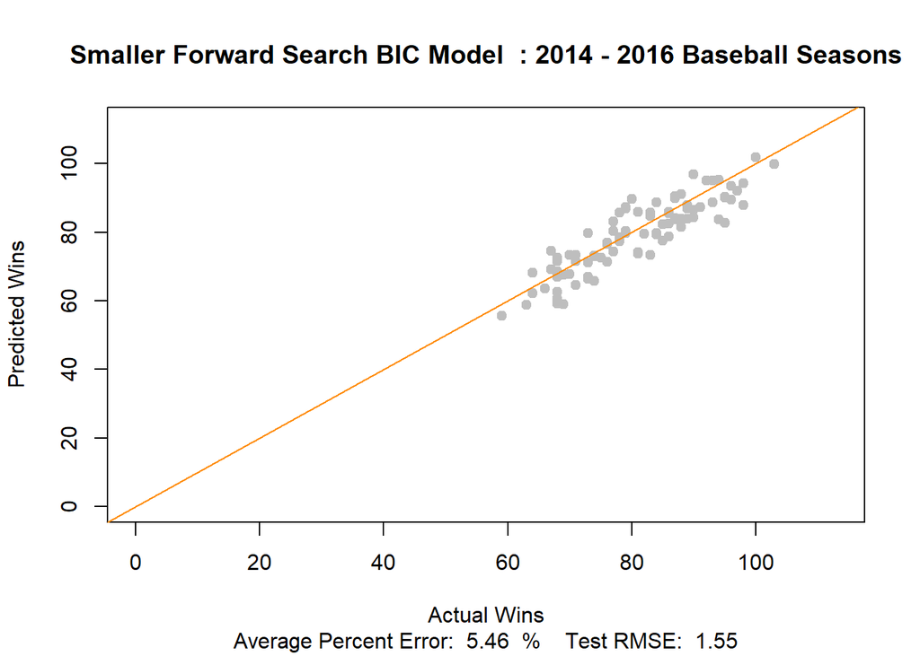

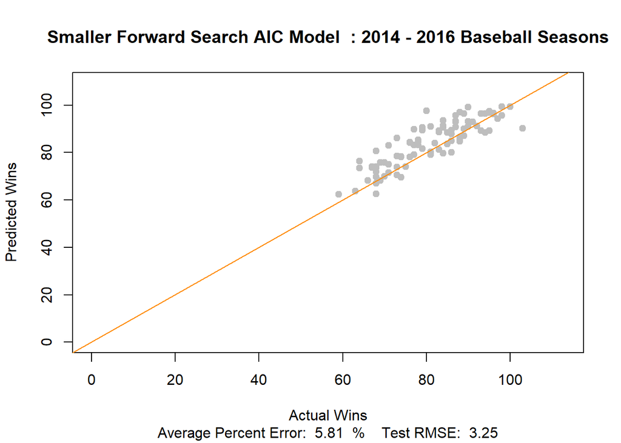

## Results

### And the Winning Linear Regression Model is…

While all models do a good job predicting the number of regular season wins by an MLB team, the **Smaller Step Search: BIC Model** produces the best results against the test dataset. This model has the lowest *Average Percent Error* score and the lowest *Test RMSE* score for predictions with the test dataset. This model also generalizes the best predictions against unseen observations. This means there is a high likelihood this model will perform well against test data for the 2017 and 2018 MLB seasons. The model also contains the second smallest number of predictors and also contains *Salary* as one of the predictors. This means it is easy to explain the relationship between the response variable **`W`** and it predictors. The fact that *Salary* is included as a predictor supports the original premise that *Salary*, while not a dominant predictor, is a marginally significant predictor of regular season MLB team wins.

The following table summarizes the key evaluation factors used to choose the best model from the five candidates.

[output not shown]

## Discussion

The winning model – *Smaller Step Search: BIC* – adds validity to the axiom that pitching wins games. The key predictors that influence the number of regular season wins by an MLB team are related to pitching.

- Holding all other predictors constant, each additional *Save* increases the average number of wins by 0.40.
- Holding all other predictors constant, each additional *Shutout* increases the average number of wins by 0.17.
- Holding all other predictors constant, each additional *Complete Game* increases the average number of wins by 0.142.
- Holding all other predictors constant, each additional run given up by a pitcher (*Runs Against*) reduces the average number of wins by 0.7.

It is moderately surprising that offense-related predictors do not dominate the model. (One of the authors of this study is a die-hard New York Yankees fan. The New York Yankees are well known for slightly above average pitching but dominant offense. The Yankees have 27 World Championships to date. That said, the last championship occurred nine years ago. So maybe there is more to good pitching than meets the eye.) The one offense-related predictor that moves the needle is *Runs*. Holding all other predictors constant, an increase in 1 run per game increases the average number of wins by 0.10.

The most exciting play in baseball, the *Triple*, is negatively correlated with wins. Holding all other predictors constant, an increase of 1 *Triple* reduces the average number of wins by 0.5. This is a real “head-scratcher.”

# Logistic Modeling and Prediction of Division Winners

## Salary as a Predictor for Division Winners

For this second thread, we turn our attention to logistic regression and our ability to classify and predict division winners using our team predictor set. First, we see how well *Salary* alone can predict pennants.

```r
salary_only_model <- glm(DivWin ~ salary, data = bbproj_trn, family = binomial)
(salary_only_summary = summary(salary_only_model))
```

```
##
## Call:
## glm(formula = DivWin ~ salary, family = binomial, data = bbproj_trn)
##
## Deviance Residuals:
##     Min       1Q   Median       3Q      Max
## -1.5538  -0.6746  -0.5664  -0.4673   2.1545
##
## Coefficients:
##                    Estimate      Std. Error z value   Pr(>|z|)
## (Intercept) -2.693550028350  0.317777033524  -8.476    < 2e-16 ***
## salary       0.000000015283  0.000000003249   4.704 0.00000255 ***
## ---
## Signif. codes:  0 '***' 0.001 '**' 0.01 '*' 0.05 '.' 0.1 ' ' 1
##
## (Dispersion parameter for binomial family taken to be 1)
##
##     Null deviance: 420.34  on 419  degrees of freedom
## Residual deviance: 397.38  on 418  degrees of freedom
## AIC: 401.38
##
## Number of Fisher Scoring iterations: 4
```

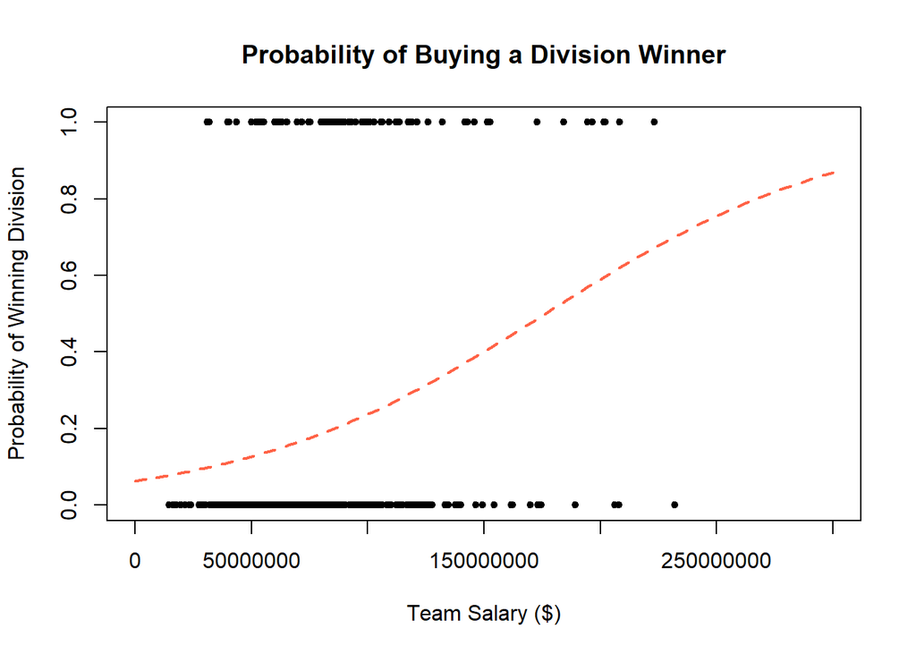

```r
plot(as.numeric(DivWin) - 1 ~ salary, data = bbproj_trn,
     pch = 20,
     main = "Probability of Buying a Division Winner",
     ylab = "Probability of Winning Division",
     xlab = "Team Salary ($)",
     xlim = c(0, 3e8))
curve(predict(salary_only_model, data.frame(salary = x), type = "response"),
      add = TRUE,
      col = "tomato",
      lty = 2,
      lwd = 2)
```

Graphically, a team’s payroll seems to be moderately influential in predicting their chances of taking home a division crown. Indeed, our Wald test for *Salary* alone yields a p-value of 0.0000025, allowing us to reject the null hypothesis ($H_0 : \beta_{salary} = 0$) for any reasonable value for $\alpha$. So what happens when we look at our salary model’s test misclassification rate?

```r
salary_prediction <- ifelse(predict(salary_only_model,
                                    bbproj_tst,
                                    type = "response") > 0.5, "Y", "N")
(prevalence = table(bbproj_tst$DivWin) / nrow(bbproj_tst))
```

```
##
##   N   Y
## 0.8 0.2
```

```r
(salary_misclass = mean(salary_prediction != bbproj_tst$DivWin))
```

```
## [1] 0.2222222
```

First, we examine prevalence of division winners. We see that 20% of the teams were division winners, which makes sense since there are 6 divisions and 30 MLB teams; therefore, you will only have 6 division winners per year. Our salary model has a misclassification rate of 0.222, which is worse than our prevalence. We would have a better misclassification rate if we simply stated that there are no division winners! We can certainly do better than this.

## Methodology

Similar to the MLR section, the ultimate goal of this thread is to find a logistic regression model that predicts well and is easily interpretable. To facilitate interpretability, we utilize the **`step`** function to capture significant predictors using both AIC and BIC criteria, searching “forward”, “backward”, and “stepwise”. We strive to minimize the number of predictors while maximizing the model’s predictive capabilities.

To predict efficiently, we develop Bayes classifiers based on the models and evaluate them by calculating their sensitivity, specificity, and misclassification rate using our test dataset from the 2014, 2015, and 2016 MLB seasons. Finally, we cross validate the misclassifications and choose a model that has the lowest 5-fold cross validation misclassification rate while keeping the other diagnostics in mind.

### Candidate Logistic Regression Models

We will begin our search for a better classifier by setting up an initial logistic regression model contain all of the predictors we would like to evaluate. Then, we will proceed to eliminate predictors using backwards, forwards, and stepwise AIC and BIC searches. See Appendix C for a complete evaluation of the remaining model derivations and classifications. The following will detail the methodology using our best candidate model.

First, we set our scope and generate our initial Generalized Linear Model with only the intercept as the predictor.

```r
scope <- DivWin ~ W + R + AB + H + X2B + X3B + HR + BB + SO + SB + CS + HBP +
  SF + RA + ER + ERA + CG + SHO + SV + IPouts + HA  + HRA + BBA + SOA + E +
  DP + FP + attendance + BPF + PPF + salary + RBI + GIDP + IBB + TB + SLG +
  OBP + OPS + WHIP + BABIP + RC + X1B + uBB + wOBA
start_model <- glm(DivWin ~ 1, data = bbproj_trn, family = binomial)
n <- length(resid(start_model))
```

#### Forward Search: AIC Model

Next, we begin to determine which predictors are influential by using the **`step`** function. In this case, we are using a forward-search algorithm using AIC criteria.

```r
aic_model <- step(start_model, direction = "forward", scope = scope,
                  trace = 0)
summary(aic_model)
```

```
##
## Call:
## glm(formula = DivWin ~ W + X2B + HA + DP + GIDP, family = binomial,
##     data = bbproj_trn)
##
## Deviance Residuals:
##      Min        1Q    Median        3Q       Max
## -2.31485  -0.25596  -0.04893  -0.00565   2.90172
##
## Coefficients:
##               Estimate Std. Error z value Pr(>|z|)
## (Intercept) -37.894889   6.186389  -6.126 9.04e-10 ***
## W             0.392678   0.048963   8.020 1.06e-15 ***
## X2B          -0.024866   0.007752  -3.208  0.00134 **
## HA            0.006988   0.002855   2.447  0.01440 *
## DP           -0.024295   0.012063  -2.014  0.04401 *
## GIDP          0.021012   0.012242   1.716  0.08609 .
## ---
## Signif. codes:  0 '***' 0.001 '**' 0.01 '*' 0.05 '.' 0.1 ' ' 1
##
## (Dispersion parameter for binomial family taken to be 1)
##
##     Null deviance: 420.34  on 419  degrees of freedom
## Residual deviance: 182.92  on 414  degrees of freedom
## AIC: 194.92
##
## Number of Fisher Scoring iterations: 7
```

Our forward-search using AIC yields the following logistic model

$$\log \bigg(\frac{P[DivWin = 1]}{1 - P[DivWin = 1]} \bigg) = \beta_0 + \beta_W W + \beta_{X2B} X2B + \beta_{HA} HA + \beta_{DP} DP + \beta_{GIDP} GIDP$$

where the log odds of a team winning their division is dependent upon cumulative wins, doubles, hits against, turned double plays, and double plays grounded into.

##### Diagnostics

First, we evaluate our model with our training data by examining its 5-fold cross-validation misclassification rate. We choose this diagnostic over the training misclassification rate to avoid giving preference to larger models. This will have the added bonus of reducing the probability of overfitting.

Here we develop a simple function to perform our cross validation (see the **`cross_validate`** function in Appendix D).

```r
(aic_cv <- cross_validate(aic_model))
```

```
## [1] 0.074031
```

This specific model performed the best out of the six selected logistic regression models with a 5-fold cross-validation misclassification rate of 0.074.

Next, we will create a function that will evaluate this model using a confusion matrix of our test data to calculate its sensitivity, specificity, and its misclassification rate (the **`classify_and_diagnose`** function code can be found in Appendix D). We will proceed with a default cutoff value of 0.5.

```r
(aic_diag <- classify_and_diagnose(aic_model))
```

```
## $confusion_matrix
##           actual
## prediction  N  Y
##          N 70  8
##          Y  2 10
##
## $sensitivity
## [1] 0.5555556
##
## $specificity
## [1] 0.9722222
##
## $misclassification
## [1] 0.1111111
```

Here, we beat the salary-only model (along with the prevalence) with a test misclassification rate of 0.111. Our specificity looks great for this model at 0.972. Our 8 false negatives could come down by adjusting our cutoff value, but the trade-off would be a lower specificity and a worse misclassification rate (that exercise is out of scope for this project).

## Results

```r
library(knitr)
kable(logistic_model_results, col.names = logistic_col_names,
      caption = "Logistic Regression Model Result Summary")
```

Logistic Regression Model Result Summary

|  | 5-Fold CV | p | Sensitivity | Specificity | False Negatives | False Positives |
| --- | --- | --- | --- | --- | --- | --- |
| Forward AIC | 0.0740310 | 6 | 0.5555556 | 0.9722222 | 8 | 2 |
| Backward AIC | 0.0823439 | 21 | 0.7222222 | 0.9722222 | 5 | 2 |
| Stepwise AIC | 0.0740310 | 6 | 0.5555556 | 0.9722222 | 8 | 2 |
| Forward BIC | 0.0757108 | 3 | 0.6111111 | 0.9722222 | 7 | 2 |
| Backward BIC | 0.0768684 | 11 | 0.6111111 | 0.9722222 | 7 | 2 |
| Stepwise BIC | 0.0757108 | 3 | 0.6111111 | 0.9722222 | 7 | 2 |

Based on our cross-validated misclassification rates, we choose the *Forward AIC* model (note that the *Stepwise AIC* model is equivalent).

$$\log \bigg(\frac{P[DivWin = 1]}{1 - P[DivWin = 1]} \bigg) = \beta_0 + \beta_W W + \beta_{X2B} X2B + \beta_{HA} HA + \beta_{DP} DP + \beta_{GIDP} GIDP$$

where the predictors are

- `W` - wins
- `X2B` - doubles
- `HA` - hits against
- `DP` - double plays
- `GIDP` - ground into double plays.

With that, we see that the *Forward BIC* model is fairly close in misclassification, but has half the number of $\beta$ parameters. Here, the *Forward BIC* model is

$$\log \bigg(\frac{P[DivWin = 1]}{1 - P[DivWin = 1]} \bigg) = \beta_0 + \beta_W W + \beta_{X2B} X2B$$

where the predictors are

- `W` - wins
- `X2B` - doubles.

We note that the smaller BIC model is nested within the larger AIC model, so we can perform a Likelihood-Ratio Test to determine if the additional parameters in the AIC model are significant.

```r
(forw_likelihood_ratio = anova(forw_bic_model, forw_aic_model, test = "LRT"))
```

```
## Analysis of Deviance Table
##
## Model 1: DivWin ~ W + X2B
## Model 2: DivWin ~ W + X2B + HA + DP + GIDP
##   Resid. Df Resid. Dev Df Deviance Pr(>Chi)
## 1       417     194.55
## 2       414     182.92  3   11.627 0.008778 **
## ---
## Signif. codes:  0 '***' 0.001 '**' 0.01 '*' 0.05 '.' 0.1 ' ' 1
```

If we commandeer the MLR thread’s value for $\alpha = 0.05$ and compare it to our test’s p-value of 0.0087778, we would reject the null hypothesis $H_0 : \beta_{HA} = \beta_{DP} = \beta_{GIDP} = 0$ and declare our preference for the larger forward-search AIC model.

### And the Winning Logistic Regression Model is…

The forward-search AIC model.

$$\log \bigg(\frac{P[DivWin = 1]}{1 - P[DivWin = 1]} \bigg) = \beta_0 + \beta_W W + \beta_{X2B} X2B + \beta_{HA} HA + \beta_{DP} DP + \beta_{GIDP} GIDP$$

## Discussion

```r
forw_aic_diag$confusion_matrix
```

```
##           actual
## prediction  N  Y
##          N 70  8
##          Y  2 10
```

Interestingly, the remaining predictors all have relationships with **`DivWin`** inverse to what we would expect. For instance, there is a somewhat-significant negative relationship with doubles, given the remaining predictors. That is, given two teams with the same number of wins, hits against, double plays, and GIDPs, the team with the *fewer* number of doubles would have a higher probability of winning its division. What does this mean? Well, one explanation could be, given all else is equal, the game favors teams proficient at small ball - being able to manufacture runs with walks, bunts, steals, and sacrifice flies - rather than a team’s capacity of lacing ropes to the alley in left-center.

Similarly, we would expect that the number of double plays a team successfully executes wouldn’t hinder its odds at winning a division. But holding the remaining predictors constant, that’s exactly what this model says. So despite the small number of predictors for this model - while it indeed predicts well - it seems it is still tricky to interpret.

# Appendices

## Appendix A - Data Preparation

In the loaddata.R script we load 3 data files “Salaries.csv”, Teams.csv and “Batting.csv.” For each, we limited the data to the years of 2000 through 2016. All 3 dataframes have factor columns that were impacted by the filtering of the data. This was corrected using the **`droplevels`** function. We then summed the Salaries data by **`YearID`** and **`TeamID`** and added that as the **`team_salaries`** column. We performed the same for the Batting data and added that as the **`team_batting`** column.

Next we added calculated columns:

- `TB` - Total bases
- `SLG` - Slugging percentage
- `OBP` - On-base percentage
- `OPS` - On-base plus slugging percentage
- `WHIP` - Walks and hits per innings pitched
- `BABIP` - Batting average for balls in play
- `RC` - Runs created
- `uBB` - Unintentional walks
- `wOBA` - Weighted on-base average

We then wrote the data out to the CSV file “bbproj.csv.”

## Appendix B - Sabermetrics

A decision was made to include a few advanced Sabermetrics in our regressions to determine if there was value in them aggregated at the team level. Typically, a player’s added value, or more precisely, the number of wins a player directly contributes to a team, cannot be established with legacy baseball statistics alone. Several advanced statistics, called Sabermetrics (loosely named after the *Society for American Baseball Research*, or SABR for short), were developed to correlate a player’s on-field statistics to team wins. Some of them were likely developed using tools described in this course.

### Total Bases

Total bases (**`TB`**) can be derived from our data using the the following relation:

$$TB = H + 2B + 2*3B + 3*HR$$

where:

- `H` is hits
- `2B` is doubles
- `3B` is triples
- `HR` is home runs

Note that in tallying bases, we multiply triples (**`3B`**) by 2 and not 3, etc., since one of the bases is already accounted for in the total hits (**`H`**) tally.

### Slugging Percentage

Slugging percentage (**`SLG`**) is calculated as the team’s total bases (**`TB`**) divided by total at bats (**`AB`**).

$$SLG = \frac{TB}{AB}$$

By dividing the total number of bases by at bats, we get a sense of how often a team gets an extra-base hit. In short, it is a measure of team power.

### On-Base Percentage

We can calculate on-base percentage using the following relation:

$$OBP = \frac{AB*(H+BB+HBP)+TB*(AB+BB+SF+HBP)}{AB*(AB+BB+SF+HBP)}$$

where:

- `AB` is at bats
- `BB` is walks
- `HBP` is hit by pitch
- `TB` is total bases
- `SF` is sacrifice flies

### OPS - On-base Plus Slugging

On base percentage (**`OBP`**) is essentially the ratio of the number of times a batter reaches base divided by the number plate appearances. It is a measure of the teams batting efficiency. Slugging percentage (**`SLG`**) is average number of bases that a player gets every time they come to bat, excluding walks.

$$OPS = OBP + SLG$$

Adding the on-base percentage and slugging percentage together, we get a good idea of the team’s efficiency and power.

### WHIP - Walks plus Hits per Innings Pitched

Is a derived pitching statistic used to evaluate a pitcher’s ability to throw “clean” innings.

$$WHIP = \frac{BB + H}{IP}$$

### BABIP - Batting Average on Balls In Play

Is a measure of a hitter’s ability to get a hit while keeping the ball in play (i.e. *without* home runs).

$$BABIP = \frac{H - HR}{AB - SO - HR + SF}$$

### RC - Runs Created

Is an attempt to directly measure the number of runs a player creates for his team.

$$RC = \frac{TB(H + BB)}{AB + BB}$$

[Runs Created](https://www.baseball-reference.com/bullpen/Runs_created) is an advanced statistic created by Bill James in the 1970’s. Interestingly, his statistic aggregated at the team level predicts runs extremely well, despite not having any statistics directly related to runs in the equation.

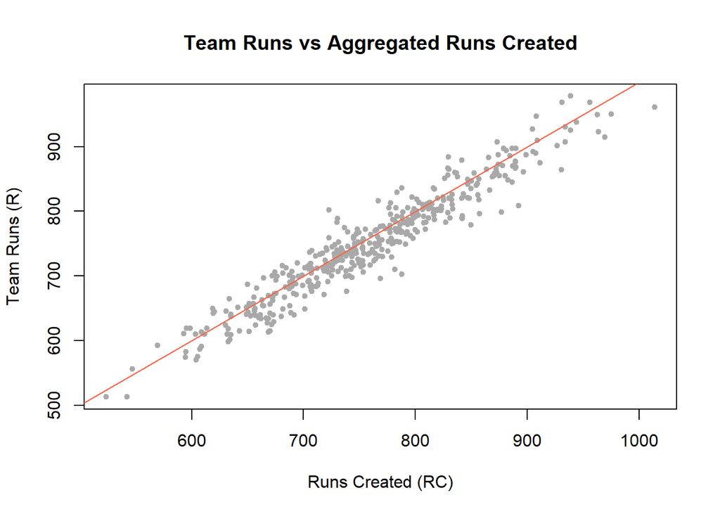

```r
plot(R ~ RC, data = bbproj_trn,
     main = "Team Runs vs Aggregated Runs Created",
     xlab = "Runs Created (RC)",
     ylab = "Team Runs (R)",
     col = "darkgray",
     pch = 20)
abline(a = 0, b = 1, col = "tomato")
```

### wOBA - Weighted On-Base Average

Is similar to on-base percentage (**`OBP`**), giving “extra credit” for extra-base hits, but not as much credit as slugging percentage (**`SLG`**).

$$wOBA = \frac{0.69 uBB + 0.72 HBP + 0.89 X1B + 1.27 X2B + 1.62 X3B + 2.1 HR}{AB + BB - IBB + SF + HBP}$$

[wOBA](https://www.fangraphs.com/library/offense/woba/) was developed by Tom Tango in 2006.

## Appendix C - Logistic Regression Models

### Backward Search: BIC Model

```r
formula <- formula(scope)
back_bic_model <- step(glm(formula, data = bbproj_trn, family = binomial),
                       direction = "backward", k = log(n), trace = 0)
back_bic_diag <- classify_and_diagnose(back_bic_model)
back_bic_cv <- cross_validate(back_bic_model)
```

```r
summary(back_bic_model)
```

```
##
## Call:
## glm(formula = DivWin ~ W + AB + H + HR + BB + HBP + IBB + SLG +
##     OBP + wOBA, family = binomial, data = bbproj_trn)
##
## Deviance Residuals:
##      Min        1Q    Median        3Q       Max
## -2.09816  -0.27642  -0.04275  -0.00332   2.76522
##
## Coefficients:
##                Estimate  Std. Error z value           Pr(>|z|)
## (Intercept) -1052.50217   319.70312  -3.292           0.000994 ***
## W               0.37031     0.04793   7.726 0.0000000000000111 ***
## AB              0.17509     0.05585   3.135           0.001717 **
## H              -0.52892     0.16383  -3.228           0.001245 **
## HR              0.09433     0.03603   2.618           0.008842 **
## BB             -0.34709     0.10338  -3.357           0.000787 ***
## HBP            -0.33911     0.09686  -3.501           0.000463 ***
## IBB            -0.30746     0.12140  -2.533           0.011320 *
## SLG          1794.92000   702.65755   2.554           0.010635 *
## OBP          6178.22128  2030.78091   3.042           0.002348 **
## wOBA        -5414.02198  2077.07626  -2.607           0.009146 **
## ---
## Signif. codes:  0 '***' 0.001 '**' 0.01 '*' 0.05 '.' 0.1 ' ' 1
##
## (Dispersion parameter for binomial family taken to be 1)
##
##     Null deviance: 420.34  on 419  degrees of freedom
## Residual deviance: 179.06  on 409  degrees of freedom
## AIC: 201.06
##
## Number of Fisher Scoring iterations: 8
```

```r
back_bic_diag
```

```
## $confusion_matrix
##           actual
## prediction  N  Y
##          N 70  7
##          Y  2 11
##
## $sensitivity
## [1] 0.6111111
##
## $specificity
## [1] 0.9722222
##
## $misclassification
## [1] 0.1
```

### Forward Search: BIC Model

```r
forw_bic_model <- step(start_model, direction = "forward", scope = scope,
                       k = log(n), trace = 0)
forw_bic_diag <- classify_and_diagnose(forw_bic_model)
forw_bic_cv <- cross_validate(forw_bic_model)
```

```r
summary(forw_bic_model)
```

```
##
## Call:
## glm(formula = DivWin ~ W + X2B, family = binomial, data = bbproj_trn)
##
## Deviance Residuals:
##      Min        1Q    Median        3Q       Max
## -2.35987  -0.30139  -0.06081  -0.00867   2.59348
##
## Coefficients:
##               Estimate Std. Error z value          Pr(>|z|)
## (Intercept) -27.523331   3.832156  -7.182 0.000000000000686 ***
## W             0.350030   0.042623   8.212           < 2e-16 ***
## X2B          -0.016344   0.006758  -2.418            0.0156 *
## ---
## Signif. codes:  0 '***' 0.001 '**' 0.01 '*' 0.05 '.' 0.1 ' ' 1
##
## (Dispersion parameter for binomial family taken to be 1)
##
##     Null deviance: 420.34  on 419  degrees of freedom
## Residual deviance: 194.55  on 417  degrees of freedom
## AIC: 200.55
##
## Number of Fisher Scoring iterations: 7
```

```r
forw_bic_diag
```

```
## $confusion_matrix
##           actual
## prediction  N  Y
##          N 70  7
##          Y  2 11
##
## $sensitivity
## [1] 0.6111111
##
## $specificity
## [1] 0.9722222
##
## $misclassification
## [1] 0.1
```

### Stepwise Search: BIC Model

```r
step_bic_model <- step(start_model, direction = "both", scope = scope,
                       k = log(n), trace = 0)
step_bic_diag <- classify_and_diagnose(step_bic_model)
step_bic_cv <- cross_validate(step_bic_model)
```

```r
summary(step_bic_model)
```

```
##
## Call:
## glm(formula = DivWin ~ W + X2B, family = binomial, data = bbproj_trn)
##
## Deviance Residuals:
##      Min        1Q    Median        3Q       Max
## -2.35987  -0.30139  -0.06081  -0.00867   2.59348
##
## Coefficients:
##               Estimate Std. Error z value          Pr(>|z|)
## (Intercept) -27.523331   3.832156  -7.182 0.000000000000686 ***
## W             0.350030   0.042623   8.212           < 2e-16 ***
## X2B          -0.016344   0.006758  -2.418            0.0156 *
## ---
## Signif. codes:  0 '***' 0.001 '**' 0.01 '*' 0.05 '.' 0.1 ' ' 1
##
## (Dispersion parameter for binomial family taken to be 1)
##
##     Null deviance: 420.34  on 419  degrees of freedom
## Residual deviance: 194.55  on 417  degrees of freedom
## AIC: 200.55
##
## Number of Fisher Scoring iterations: 7
```

```r
step_bic_diag
```

```
## $confusion_matrix
##           actual
## prediction  N  Y
##          N 70  7
##          Y  2 11
##
## $sensitivity
## [1] 0.6111111
##
## $specificity
## [1] 0.9722222
##
## $misclassification
## [1] 0.1
```

### Backward Search: AIC Model

```r
formula <- formula(scope)
back_aic_model <- step(glm(formula, data = bbproj_trn, family = binomial),
                       direction = "backward", trace = 0)
back_aic_diag <- classify_and_diagnose(back_aic_model)
back_aic_cv <- cross_validate(back_aic_model)
```

```r
summary(back_aic_model)
```

```
##
## Call:
## glm(formula = DivWin ~ W + R + AB + H + HR + BB + CS + HBP +
##     ER + IPouts + E + FP + BPF + PPF + RBI + IBB + SLG + OBP +
##     OPS + wOBA, family = binomial, data = bbproj_trn)
##
## Deviance Residuals:
##      Min        1Q    Median        3Q       Max
## -1.96822  -0.20843  -0.02111  -0.00065   2.65771
##
## Coefficients:
##                      Estimate        Std. Error z value      Pr(>|z|)
## (Intercept)       -140.179268        693.655435  -0.202      0.839848
## W                    0.545656          0.090798   6.010 0.00000000186 ***
## R                   -0.076857          0.035782  -2.148      0.031717 *
## AB                   0.183520          0.063041   2.911      0.003601 **
## H                   -0.592491          0.183941  -3.221      0.001277 **
## HR                   0.079762          0.041066   1.942      0.052099 .
## BB                  -0.401042          0.116424  -3.445      0.000572 ***
## CS                  -0.059004          0.023336  -2.528      0.011457 *
## HBP                 -0.393193          0.110648  -3.554      0.000380 ***
## ER                   0.024676          0.008386   2.943      0.003255 **
## IPouts               0.022175          0.011255   1.970      0.048806 *
## E                   -0.168360          0.092043  -1.829      0.067378 .
## FP               -1111.221677        583.517328  -1.904      0.056865 .
## BPF                  0.736250          0.339446   2.169      0.030084 *
## PPF                 -0.674039          0.343047  -1.965      0.049430 *
## RBI                  0.070973          0.036748   1.931      0.053438 .
## IBB                 -0.299451          0.134303  -2.230      0.025769 *
## SLG          851959694.753834  417793029.895435   2.039      0.041431 *
## OBP          851964527.212391  417793070.982018   2.039      0.041430 *
## OPS         -851957931.270739  417793013.312068  -2.039      0.041431 *
## wOBA             -5332.125386       2319.745911  -2.299      0.021529 *
## ---
## Signif. codes:  0 '***' 0.001 '**' 0.01 '*' 0.05 '.' 0.1 ' ' 1
##
## (Dispersion parameter for binomial family taken to be 1)
##
##     Null deviance: 420.34  on 419  degrees of freedom
## Residual deviance: 151.22  on 399  degrees of freedom
## AIC: 193.22
##
## Number of Fisher Scoring iterations: 8
```

```r
back_aic_diag <- classify_and_diagnose(back_aic_model)
```

### Forward Search: AIC Model

```r
forw_aic_model <- step(start_model, direction = "forward",
                       scope = scope, trace = 0)
forw_aic_diag <- classify_and_diagnose(forw_aic_model)
forw_aic_cv <- cross_validate(forw_aic_model)
```

```r
summary(forw_aic_model)
```

```
##
## Call:
## glm(formula = DivWin ~ W + X2B + HA + DP + GIDP, family = binomial,
##     data = bbproj_trn)
##
## Deviance Residuals:
##      Min        1Q    Median        3Q       Max
## -2.31485  -0.25596  -0.04893  -0.00565   2.90172
##
## Coefficients:
##               Estimate Std. Error z value Pr(>|z|)
## (Intercept) -37.894889   6.186389  -6.126 9.04e-10 ***
## W             0.392678   0.048963   8.020 1.06e-15 ***
## X2B          -0.024866   0.007752  -3.208  0.00134 **
## HA            0.006988   0.002855   2.447  0.01440 *
## DP           -0.024295   0.012063  -2.014  0.04401 *
## GIDP          0.021012   0.012242   1.716  0.08609 .
## ---
## Signif. codes:  0 '***' 0.001 '**' 0.01 '*' 0.05 '.' 0.1 ' ' 1
##
## (Dispersion parameter for binomial family taken to be 1)
##
##     Null deviance: 420.34  on 419  degrees of freedom
## Residual deviance: 182.92  on 414  degrees of freedom
## AIC: 194.92
##
## Number of Fisher Scoring iterations: 7
```

```r
forw_aic_diag
```

```
## $confusion_matrix
##           actual
## prediction  N  Y
##          N 70  8
##          Y  2 10
##
## $sensitivity
## [1] 0.5555556
##
## $specificity
## [1] 0.9722222
##
## $misclassification
## [1] 0.1111111
```

### Stepwise Search: AIC Model

```r
step_aic_model <- step(start_model, direction = "both",
                       scope = scope, trace = 0)
step_aic_diag <- classify_and_diagnose(step_aic_model)
step_aic_cv <- cross_validate(step_aic_model)
```

```r
summary(step_aic_model)
```

```
##
## Call:
## glm(formula = DivWin ~ W + X2B + HA + DP + GIDP, family = binomial,
##     data = bbproj_trn)
##
## Deviance Residuals:
##      Min        1Q    Median        3Q       Max
## -2.31485  -0.25596  -0.04893  -0.00565   2.90172
##
## Coefficients:
##               Estimate Std. Error z value Pr(>|z|)
## (Intercept) -37.894889   6.186389  -6.126 9.04e-10 ***
## W             0.392678   0.048963   8.020 1.06e-15 ***
## X2B          -0.024866   0.007752  -3.208  0.00134 **
## HA            0.006988   0.002855   2.447  0.01440 *
## DP           -0.024295   0.012063  -2.014  0.04401 *
## GIDP          0.021012   0.012242   1.716  0.08609 .
## ---
## Signif. codes:  0 '***' 0.001 '**' 0.01 '*' 0.05 '.' 0.1 ' ' 1
##
## (Dispersion parameter for binomial family taken to be 1)
##
##     Null deviance: 420.34  on 419  degrees of freedom
## Residual deviance: 182.92  on 414  degrees of freedom
## AIC: 194.92
##
## Number of Fisher Scoring iterations: 7
```

```r
step_aic_diag
```

```
## $confusion_matrix
##           actual
## prediction  N  Y
##          N 70  8
##          Y  2 10
##
## $sensitivity
## [1] 0.5555556
##
## $specificity
## [1] 0.9722222
##
## $misclassification
## [1] 0.1111111
```

## Appendix D - Logistic Regression Diagnostic Functions

### Cross-Validation Misclassification Rate Function

```r
cross_validate = function(model, data = bbproj_trn, folds = 5) {
  set.seed(42)
  boot::cv.glm(data, model, K = folds)$delta[1]
}
```

### Classify and Diagnose Function

```r
classify_and_diagnose = function(model, data = bbproj_tst,
                                 actual = bbproj_tst$DivWin,
                                 pos = "Y", neg = "N", cutoff = 0.5) {
  # Generate a classifier given the model, data, cutoff, and positive and
  # negative responses
  pred = ifelse(predict(model,
                        data,
                        type = "response") > cutoff, pos, neg)

  # Generate the confusion matrix
  conf_mat = table(prediction = pred, actual = actual)

  # Calculate sensitivity, specificity, and the misclassification rate and
  # return them plus the confusion matrix
  list(confusion_matrix = conf_mat,
       sensitivity = conf_mat[2, 2] / sum(conf_mat[, 2]),
       specificity = conf_mat[1, 1] / sum(conf_mat[, 1]),
       misclassification = mean(pred != actual))
}
```